# tp1

340. 'Cool Hand Luke (1967)'

341. 'Cool Runnings (1993)'

342. 'Cop Land (1997)'

343. 'Cops and Robbersons (1994)'

344. 'Copycat (1995)'

345. 'Corrina, Corrina (1994)'

346. 'Cosi (1996)'

347. 'Country Life (1994)'

348. 'Courage Under Fire (1996)'

349. 'Cowboy Way, The (1994)'

350. 'Craft, The (1996)'

351. 'Crash (1996)'

352. 'Crimson Tide (1995)'

353. 'Critical Care (1997)'

354. 'Cronos (1992)'

355. 'Crooklyn (1994)'

356. 'Crossfire (1947)'

357. 'Crossing Guard, The (1995)'

358. 'Crow, The (1994)'

359. 'Crow: City of Angels, The (1996)'

360. 'Crows and Sparrows (1949)'

361. 'Crucible, The (1996)'

362. 'Crude Oasis, The (1995)'

363. 'Crumb (1994)'

364. 'Cry, the Beloved Country (1995)'

365. 'Crying Game, The (1992)'

366. 'Curdled (1996)'

367. 'Cure, The (1995)'

368. 'Cutthroat Island (1995)'

369. 'Cyclo (1995)'

370. 'Cyrano de Bergerac (1990)'

371. 'D3: The Mighty Ducks (1996)'

372. 'Dadetown (1995)'

373. 'Daens (1992)'

374. 'Damsel in Distress, A (1937)'

375. 'Dances with Wolves (1990)'

376. 'Dangerous Beauty (1998)'

377. 'Dangerous Ground (1997)'

378. 'Dangerous Minds (1995)'

379. 'Daniel Defoe\'s Robinson Crusoe (1996)'

380. 'Dante\'s Peak (1997)'

381. 'Dark City (1998)'

382. 'Dave (1993)'

383. 'Davy Crockett, King of the Wild Frontier (1955)'

384. 'Day the Earth Stood Still, The (1951)'

385. 'Day the Sun Turned Cold, The (Tianguo niezi) (1994)'

386. 'Daylight (1996)'

387. 'Days of Thunder (1990)'

388. 'Daytrippers, The (1996)'

389. 'Dazed and Confused (1993)'

390. 'Dead Man (1995)'

391. 'Dead Man Walking (1995)'

392. 'Dead Poets Society (1989)'

393. 'Dead Presidents (1995)'

394. 'Dear God (1996)'

395. 'Death and the Maiden (1994)'

396. 'Death in Brunswick (1991)'

397. 'Death in the Garden (Mort en ce jardin, La) (1956)'

398. 'Deceiver (1997)'

399. 'Deconstructing Harry (1997)'

400. 'Deep Rising (1998)'

401. 'Deer Hunter, The (1978)'

402. 'Delicatessen (1991)'

403. 'Delta of Venus (1994)'

404. 'Demolition Man (1993)'

405. 'Denise Calls Up (1995)'

406. 'Desert Winds (1995)'

407. 'Designated Mourner, The (1997)'

408. 'Desperado (1995)'

409. 'Desperate Measures (1998)'

410. 'Destiny Turns on the Radio (1995)'

411. 'Devil in a Blue Dress (1995)'

412. 'Devil\'s Advocate, The (1997)'

413. 'Devil\'s Own, The (1997)'

414. 'Diabolique (1996)'

415. 'Dial M for Murder (1954)'

416. 'Die Hard (1988)'

417. 'Die Hard 2 (1990)'

418. 'Die Hard: With a Vengeance (1995)'

419. 'Die xue shuang xiong (Killer, The) (1989)'

420. 'Dingo (1992)'

421. 'Dirty Dancing (1987)'

422. 'Disclosure (1994)'

423. 'Diva (1981)'

424. 'Dolores Claiborne (1994)'

425. 'Don Juan DeMarco (1995)'

426. 'Don\'t Be a Menace to South Central While Drinking Your Juice in the Hood (1996)'

427. 'Donnie Brasco (1997)'

428. 'Doom Generation, The (1995)'

429. 'Doors, The (1991)'

430. 'Double Happiness (1994)'

431. 'Double Team (1997)'

432. 'Double vie de Véronique, La (Double Life of Veronique, The) (1991)'

433. 'Down by Law (1986)'

434. 'Down Periscope (1996)'

435. 'Dr. Strangelove or: How I Learned to Stop Worrying and Love the Bomb (1963)'

436. 'Dracula: Dead and Loving It (1995)'

437. 'Dragonheart (1996)'

438. 'Dream Man (1995)'

439. 'Dream With the Fishes (1997)'

440. 'Drop Dead Fred (1991)'

441. 'Drop Zone (1994)'

442. 'Drunks (1995)'

443. 'Duck Soup (1933)'

444. 'Dumb & Dumber (1994)'

445. 'Dumbo (1941)'

446. 'Dunston Checks In (1996)'

447. 'Duoluo tianshi (1995)'

448. 'E.T. the Extra-Terrestrial (1982)'

449. 'East of Eden (1955)'

450. 'Eat Drink Man Woman (1994)'

451. 'Ed (1996)'

452. 'Ed Wood (1994)'

453. 'Ed\'s Next Move (1996)'

454. 'Eddie (1996)'

455. 'Edge, The (1997)'

456. 'Eighth Day, The (1996)'

457. 'Emma (1996)'

458. 'Empire Strikes Back, The (1980)'

459. 'Enchanted April (1991)'

460. 'Endless Summer 2, The (1994)'

461. 'Enfer, L\' (1994)'

462. 'English Patient, The (1996)'

463. 'Englishman Who Went Up a Hill, But Came Down a Mountain, The (1995)'

464. 'Entertaining Angels: The Dorothy Day Story (1996)'

465. 'Eraser (1996)'

466. 'Escape from L.A. (1996)'

467. 'Escape from New York (1981)'

468. 'Escape to Witch Mountain (1975)'

469. 'Etz Hadomim Tafus (Under the Domin Tree) (1994)'

470. 'Eve\'s Bayou (1997)'

471. 'Even Cowgirls Get the Blues (1993)'

472. 'Evening Star, The (1996)'

473. 'Event Horizon (1997)'

474. 'Everest (1998)'

475. 'Every Other Weekend (1990)'

476. 'Everyone Says I Love You (1996)'

477. 'Evil Dead II (1987)'

478. 'Evita (1996)'

479. 'Excess Baggage (1997)'

480. 'Executive Decision (1996)'

481. 'Exit to Eden (1994)'

482. 'Exotica (1994)'

483. 'Extreme Measures (1996)'

484. 'Eye for an Eye (1996)'

485. 'Eye of Vichy, The (Oeil de Vichy, L\') (1993)'

486. 'Face/Off (1997)'

487. 'Faces (1968)'

488. 'Fair Game (1995)'

489. 'FairyTale: A True Story (1997)'

490. 'Faithful (1996)'

491. 'Fall (1997)'

492. 'Fallen (1998)'

493. 'Falling in Love Again (1980)'

494. 'Family Thing, A (1996)'

495. 'Fan, The (1996)'

496. 'Fantasia (1940)'

497. 'Far From Home: The Adventures of Yellow Dog (1995)'

498. 'Farewell My Concubine (1993)'

499. 'Farewell to Arms, A (1932)'

500. 'Fargo (1996)'

501. 'Farinelli: il castrato (1994)'

502. 'Farmer & Chase (1995)'

503. 'Fast, Cheap & Out of Control (1997)'

504. 'Faster Pussycat! Kill! Kill! (1965)'

505. 'Fatal Instinct (1993)'

506. 'Father of the Bride (1950)'

507. 'Father of the Bride Part II (1995)'

508. 'Fathers\' Day (1997)'

509. 'Faust (1994)'

510. 'Fausto (1993)'

511. 'Favor, The (1994)'

512. 'Fear (1996)'

513. 'Fear of a Black Hat (1993)'

514. 'Fear, The (1995)'

515. 'Fearless (1993)'

516. 'Feast of July (1995)'

517. 'Feeling Minnesota (1996)'

518. 'Female Perversions (1996)'

519. 'Field of Dreams (1989)'

520. 'Fierce Creatures (1997)'

521. 'Fifth Element, The (1997)'

522. 'Fille seule, La (A Single Girl) (1995)'

523. 'Fire Down Below (1997)'

524. 'Fire on the Mountain (1996)'

525. 'Firestorm (1998)'

526. 'Firm, The (1993)'

527. 'First Kid (1996)'

528. 'First Knight (1995)'

529. 'First Wives Club, The (1996)'

530. 'Fish Called Wanda, A (1988)'

531. 'Fled (1996)'

532. 'Flesh and Bone (1993)'

533. 'Flintstones, The (1994)'

534. 'Flipper (1996)'

535. 'Flirt (1995)'

536. 'Flirting With Disaster (1996)'

537. 'Flower of My Secret, The (Flor de mi secreto, La) (1995)'

538. 'Flubber (1997)'

539. 'Fluke (1995)'

540. 'Fly Away Home (1996)'

541. 'Fog, The (1980)'

542. 'Fools Rush In (1997)'

543. 'For Ever Mozart (1996)'

544. 'For Love or Money (1993)'

545. 'For Richer or Poorer (1997)'

546. 'For the Moment (1994)'

547. 'For Whom the Bell Tolls (1943)'

548. 'Forbidden Christ, The (Cristo proibito, Il) (1950)'

549. 'Forbidden Planet (1956)'

550. 'Foreign Correspondent (1940)'

551. 'Foreign Student (1994)'

552. 'Forget Paris (1995)'

553. 'Forrest Gump (1994)'

554. 'Four Days in September (1997)'

555. 'Four Rooms (1995)'

556. 'Four Weddings and a Funeral (1994)'

557. 'Fox and the Hound, The (1981)'

558. 'Foxfire (1996)'

559. 'Frankie Starlight (1995)'

560. 'Free Willy (1993)'

561. 'Free Willy 2: The Adventure Home (1995)'

562. 'Free Willy 3: The Rescue (1997)'

563. 'Freeway (1996)'

564. 'French Kiss (1995)'

565. 'French Twist (Gazon maudit) (1995)'

566. 'Fresh (1994)'

567. 'Friday (1995)'

568. 'Fried Green Tomatoes (1991)'

569. 'Frighteners, The (1996)'

570. 'Frisk (1995)'

571. 'From Dusk Till Dawn (1996)'

572. 'Fugitive, The (1993)'

573. 'Full Metal Jacket (1987)'

574. 'Full Monty, The (1997)'

575. 'Full Speed (1996)'

576. 'Funeral, The (1996)'

577. 'Funny Face (1957)'

578. 'Further Gesture, A (1996)'

579. 'G.I. Jane (1997)'

580. 'Gabbeh (1996)'

581. 'Game, The (1997)'

582. 'Gandhi (1982)'

583. 'Gang Related (1997)'

584. 'Garden of Finzi-Contini, The (Giardino dei Finzi-Contini, Il) (1970)'

585. 'Gaslight (1944)'

586. 'Gate of Heavenly Peace, The (1995)'

587. 'Gattaca (1997)'

588. 'Gay Divorcee, The (1934)'

589. 'George of the Jungle (1997)'

590. 'Georgia (1995)'

591. 'Germinal (1993)'

592. 'Geronimo: An American Legend (1993)'

593. 'Get on the Bus (1996)'

594. 'Get Shorty (1995)'

595. 'Getaway, The (1994)'

596. 'Getting Away With Murder (1996)'

597. 'Getting Even with Dad (1994)'

598. 'Ghost (1990)'

599. 'Ghost and Mrs. Muir, The (1947)'

600. 'Ghost and the Darkness, The (1996)'

601. 'Ghost in the Shell (Kokaku kidotai) (1995)'

602. 'Ghosts of Mississippi (1996)'

603. 'Giant (1956)'

604. 'Gigi (1958)'

605. 'Gilligan\'s Island: The Movie (1998)'

606. 'Girl 6 (1996)'

607. 'Girl in the Cadillac (1995)'

608. 'Girls Town (1996)'

609. 'Glass Shield, The (1994)'

610. 'Glengarry Glen Ross (1992)'

611. 'Glimmer Man, The (1996)'

612. 'Glory (1989)'

613. 'Go Fish (1994)'

614. 'Godfather, The (1972)'

615. 'Godfather: Part II, The (1974)'

616. 'Gold Diggers: The Secret of Bear Mountain (1995)'

617. 'Golden Earrings (1947)'

618. 'GoldenEye (1995)'

619. 'Gone Fishin\' (1997)'

620. 'Gone with the Wind (1939)'

621. 'Good Man in Africa, A (1994)'

622. 'Good Morning (1971)'

623. 'Good Will Hunting (1997)'

624. 'Good, The Bad and The Ugly, The (1966)'

625. 'GoodFellas (1990)'

626. 'Goofy Movie, A (1995)'

627. 'Gordy (1995)'

628. 'Grace of My Heart (1996)'

629. 'Graduate, The (1967)'

630. 'Grand Day Out, A (1992)'

631. 'Grass Harp, The (1995)'

632. 'Grateful Dead (1995)'

633. 'Grease (1978)'

634. 'Grease 2 (1982)'

635. 'Great Day in Harlem, A (1994)'

636. 'Great Dictator, The (1940)'

637. 'Great Escape, The (1963)'

638. 'Great Expectations (1998)'

639. 'Great Race, The (1965)'

640. 'Great White Hype, The (1996)'

641. 'Gridlock\'d (1997)'

642. 'Grifters, The (1990)'

643. 'Grosse Fatigue (1994)'

644. 'Grosse Pointe Blank (1997)'

645. 'Groundhog Day (1993)'

646. 'Grumpier Old Men (1995)'

647. 'Guantanamera (1994)'

648. 'Guilty as Sin (1993)'

649. 'Gumby: The Movie (1995)'

650. 'Hackers (1995)'

651. 'Half Baked (1998)'

652. 'Halloween: The Curse of Michael Myers (1995)'

653. 'Hamlet (1996)'

654. 'Hana-bi (1997)'

655. 'Happy Gilmore (1996)'

656. 'Hard Eight (1996)'

657. 'Hard Rain (1998)'

658. 'Hard Target (1993)'

659. 'Harlem (1993)'

660. 'Harold and Maude (1971)'

661. 'Harriet the Spy (1996)'

662. 'Hate (Haine, La) (1995)'

663. 'Haunted World of Edward D. Wood Jr., The (1995)'

664. 'He Walked by Night (1948)'

665. 'Head Above Water (1996)'

666. 'Hear My Song (1991)'

667. 'Hearts and Minds (1996)'

668. 'Heat (1995)'

669. 'Heathers (1989)'

670. 'Heaven & Earth (1993)'

671. 'Heaven\'s Prisoners (1996)'

672. 'Heavenly Creatures (1994)'

673. 'Heavy (1995)'

674. 'Heavy Metal (1981)'

675. 'Heavyweights (1994)'

676. 'Hedd Wyn (1992)'

677. 'Heidi Fleiss: Hollywood Madam (1995) '

678. 'Hellraiser: Bloodline (1996)'

679. 'Henry V (1989)'

680. 'Herbie Rides Again (1974)'

681. 'Hercules (1997)'

682. 'Here Comes Cookie (1935)'

683. 'Hideaway (1995)'

684. 'High Noon (1952)'

685. 'High School High (1996)'

686. 'Higher Learning (1995)'

687. 'Highlander (1986)'

688. 'Highlander III: The Sorcerer (1994)'

689. 'His Girl Friday (1940)'

690. 'Hollow Reed (1996)'

691. 'Homage (1995)'

692. 'Home Alone (1990)'

693. 'Home Alone 3 (1997)'

694. 'Home for the Holidays (1995)'

695. 'Homeward Bound II: Lost in San Francisco (1996)'

696. 'Homeward Bound: The Incredible Journey (1993)'

697. 'Hoodlum (1997)'

698. 'Hoop Dreams (1994)'

699. 'Horse Whisperer, The (1998)'

700. 'Horseman on the Roof, The (Hussard sur le toit, Le) (1995)'

701. 'Hostile Intentions (1994)'

702. 'Hot Shots! Part Deux (1993)'

703. 'Hotel de Love (1996)'

704. 'Hour of the Pig, The (1993)'

705. 'House Arrest (1996)'

706. 'House of the Spirits, The (1993)'

707. 'House of Yes, The (1997)'

708. 'House Party 3 (1994)'

709. 'Houseguest (1994)'

710. 'How to Be a Player (1997)'

711. 'How to Make an American Quilt (1995)'

712. 'Howling, The (1981)'

713. 'Hudsucker Proxy, The (1994)'

714. 'Hugo Pool (1997)'

715. 'Hunchback of Notre Dame, The (1996)'

716. 'Hungarian Fairy Tale, A (1987)'

717. 'Hunt for Red October, The (1990)'

718. 'Hunted, The (1995)'

719. 'Hurricane Streets (1998)'

720. 'Hush (1998)'

721. 'I Can\'t Sleep (J\'ai pas sommeil) (1994)'

722. 'I Don\'t Want to Talk About It (De eso no se habla) (1993)'

723. 'I Know What You Did Last Summer (1997)'

724. 'I Like It Like That (1994)'

725. 'I Love Trouble (1994)'

726. 'I Shot Andy Warhol (1996)'

727. 'I, Worst of All (Yo, la peor de todas) (1990)'

728. 'I.Q. (1994)'

729. 'I\'ll Do Anything (1994)'

730. 'I\'m Not Rappaport (1996)'

731. 'Ice Storm, The (1997)'

732. 'If Lucy Fell (1996)'

733. 'Ill Gotten Gains (1997)'

734. 'Immortal Beloved (1994)'

735. 'In & Out (1997)'

736. 'In Love and War (1996)'

737. 'In the Army Now (1994)'

738. 'In the Bleak Midwinter (1995)'

739. 'In the Company of Men (1997)'

740. 'In the Line of Duty 2 (1987)'

741. 'In the Line of Fire (1993)'

742. 'In the Mouth of Madness (1995)'

743. 'In the Name of the Father (1993)'

744. 'In the Realm of the Senses (Ai no corrida) (1976)'

745. 'Incognito (1997)'

746. 'Independence Day (ID4) (1996)'

747. 'Indian in the Cupboard, The (1995)'

748. 'Indian Summer (1996)'

749. 'Indiana Jones and the Last Crusade (1989)'

750. 'Infinity (1996)'

751. 'Inkwell, The (1994)'

752. 'Innocent Sleep, The (1995)'

753. 'Innocents, The (1961)'

754. 'Inspector General, The (1949)'

755. 'Interview with the Vampire (1994)'

756. 'Intimate Relations (1996)'

757. 'Inventing the Abbotts (1997)'

758. 'Invitation, The (Zaproszenie) (1986)'

759. 'Island of Dr. Moreau, The (1996)'

760. 'It Could Happen to You (1994)'

761. 'It Happened One Night (1934)'

762. 'It Takes Two (1995)'

763. 'It\'s a Wonderful Life (1946)'

764. 'It\'s My Party (1995)'

765. 'Jack (1996)'

766. 'Jack and Sarah (1995)'

767. 'Jackal, The (1997)'

768. 'Jackie Brown (1997)'

769. 'Jackie Chan\'s First Strike (1996)'

770. 'Jade (1995)'

771. 'James and the Giant Peach (1996)'

772. 'Jane Eyre (1996)'

773. 'Jason\'s Lyric (1994)'

774. 'Jaws (1975)'

775. 'Jaws 2 (1978)'

776. 'Jaws 3-D (1983)'

777. 'Jean de Florette (1986)'

778. 'Jefferson in Paris (1995)'

779. 'Jeffrey (1995)'

780. 'Jerky Boys, The (1994)'

781. 'Jerry Maguire (1996)'

782. 'Jimmy Hollywood (1994)'

783. 'Jingle All the Way (1996)'

784. 'JLG/JLG - autoportrait de décembre (1994)'

785. 'Joe\'s Apartment (1996)'

786. 'Johnny 100 Pesos (1993)'

787. 'Johnny Mnemonic (1995)'

788. 'Johns (1996)'

789. 'Journey of August King, The (1995)'

790. 'Joy Luck Club, The (1993)'

791. 'Jude (1996)'

792. 'Judge Dredd (1995)'

793. 'Judgment Night (1993)'

794. 'Jumanji (1995)'

795. 'Jungle Book, The (1994)'

796. 'Jungle2Jungle (1997)'

797. 'Junior (1994)'

798. 'Jupiter\'s Wife (1994)'

799. 'Jurassic Park (1993)'

800. 'Juror, The (1996)'

801. 'Jury Duty (1995)'

802. 'Just Cause (1995)'

803. 'Kalifornia (1993)'

804. 'Kama Sutra: A Tale of Love (1996)'

805. 'Kansas City (1996)'

806. 'Kaspar Hauser (1993)'

807. 'Kazaam (1996)'

808. 'Keys to Tulsa (1997)'

809. 'Kicked in the Head (1997)'

810. 'Kicking and Screaming (1995)'

811. 'Kid in King Arthur\'s Court, A (1995)'

812. 'Kids (1995)'

813. 'Kids in the Hall: Brain Candy (1996)'

814. 'Kika (1993)'

815. 'Killer (Bulletproof Heart) (1994)'

816. 'Killer: A Journal of Murder (1995)'

817. 'Killing Fields, The (1984)'

818. 'Killing Zoe (1994)'

819. 'Kim (1950)'

820. 'King of New York (1990)'

821. 'King of the Hill (1993)'

822. 'Kingpin (1996)'

823. 'Kiss Me, Guido (1997)'

824. 'Kiss of Death (1995)'

825. 'Kiss the Girls (1997)'

826. 'Kissed (1996)'

827. 'Kolya (1996)'

828. 'Koyaanisqatsi (1983)'

829. 'Kull the Conqueror (1997)'

830. 'Kundun (1997)'

831. 'L.A. Confidential (1997)'

832. 'Lady of Burlesque (1943)'

833. 'Ladybird Ladybird (1994)'

834. 'Lamerica (1994)'

835. 'Land and Freedom (Tierra y libertad) (1995)'

836. 'Land Before Time III: The Time of the Great Giving (1995) (V)'

837. 'Larger Than Life (1996)'

838. 'Lashou shentan (1992)'

839. 'Lassie (1994)'

840. 'Last Action Hero (1993)'

841. 'Last Dance (1996)'

842. 'Last Klezmer: Leopold Kozlowski, His Life and Music, The (1995)'

843. 'Last Man Standing (1996)'

844. 'Last of the Mohicans, The (1992)'

845. 'Last Summer in the Hamptons (1995)'

846. 'Last Supper, The (1995)'

847. 'Last Time I Committed Suicide, The (1997)'

848. 'Last Time I Saw Paris, The (1954)'

849. 'Late Bloomers (1996)'

850. 'Laura (1944)'

851. 'Lawnmower Man 2: Beyond Cyberspace (1996)'

852. 'Lawnmower Man, The (1992)'

853. 'Lawrence of Arabia (1962)'

854. 'Lay of the Land, The (1997)'

855. 'Leading Man, The (1996)'

856. 'Leave It to Beaver (1997)'

857. 'Leaving Las Vegas (1995)'

858. 'Legal Deceit (1997)'

859. 'Legends of the Fall (1994)'

860. 'Leopard Son, The (1996)'

861. 'Letter From Death Row, A (1998)'

862. 'Liar Liar (1997)'

863. 'Liebelei (1933)'

864. 'Life Less Ordinary, A (1997)'

865. 'Life with Mikey (1993)'

866. 'Lightning Jack (1994)'

867. 'Like Water For Chocolate (Como agua para chocolate) (1992)'

868. 'Line King: Al Hirschfeld, The (1996)'

869. 'Lion King, The (1994)'

870. 'Little Big League (1994)'

871. 'Little Buddha (1993)'

872. 'Little City (1998)'

873. 'Little Lord Fauntleroy (1936)'

874. 'Little Odessa (1994)'

875. 'Little Princess, A (1995)'

876. 'Little Princess, The (1939)'

877. 'Little Rascals, The (1994)'

878. 'Little Women (1994)'

879. 'Live Nude Girls (1995)'

880. 'Living in Oblivion (1995)'

881. 'Loaded (1994)'

882. 'Local Hero (1983)'

883. 'Loch Ness (1995)'

884. 'Locusts, The (1997)'

885. 'Lone Star (1996)'

886. 'Long Kiss Goodnight, The (1996)'

887. 'Looking for Richard (1996)'

888. 'Lord of Illusions (1995)'

889. 'Losing Chase (1996)'

890. 'Losing Isaiah (1995)'

891. 'Lost Highway (1997)'

892. 'Lost Horizon (1937)'

893. 'Lost in Space (1998)'

894. 'Lost World: Jurassic Park, The (1997)'

895. 'Lotto Land (1995)'

896. 'Love & Human Remains (1993)'

897. 'Love Affair (1994)'

898. 'Love and a .45 (1994)'

899. 'Love and Death on Long Island (1997)'

900. 'Love and Other Catastrophes (1996)'

901. 'Love Bug, The (1969)'

902. 'Love in the Afternoon (1957)'

903. 'Love Is All There Is (1996)'

904. 'Love Jones (1997)'

905. 'Love Serenade (1996)'

906. 'Love! Valour! Compassion! (1997)'

907. 'Lover\'s Knot (1996)'

908. 'Low Down Dirty Shame, A (1994)'

909. 'Low Life, The (1994)'

910. 'M (1931)'

911. 'M. Butterfly (1993)'

912. 'M*A*S*H (1970)'

913. 'Ma vie en rose (My Life in Pink) (1997)'

914. 'Machine, The (1994)'

915. 'Mad City (1997)'

916. 'Mad Dog Time (1996)'

917. 'Mad Love (1995)'

918. 'Madame Butterfly (1995)'

919. 'Made in America (1993)'

920. 'Madness of King George, The (1994)'

921. 'Madonna: Truth or Dare (1991)'

922. 'Magic Hour, The (1998)'

923. 'Magnificent Seven, The (1954)'

924. 'Major Payne (1994)'

925. 'Malice (1993)'

926. 'Mallrats (1995)'

927. 'Maltese Falcon, The (1941)'

928. 'Mamma Roma (1962)'

929. 'Man from Down Under, The (1943)'

930. 'Man in the Iron Mask, The (1998)'

931. 'Man of No Importance, A (1994)'

932. 'Man of the House (1995)'

933. 'Man of the Year (1995)'

934. 'Man Who Knew Too Little, The (1997)'

935. 'Man Who Would Be King, The (1975)'

936. 'Man Without a Face, The (1993)'

937. 'Manchurian Candidate, The (1962)'

938. 'Manhattan (1979)'

939. 'Manhattan Murder Mystery (1993)'

940. 'Manny & Lo (1996)'

941. 'Manon of the Spring (Manon des sources) (1986)'

942. 'Margaret\'s Museum (1995)'

943. 'Mark of Zorro, The (1940)'

944. 'Marked for Death (1990)'

945. 'Marlene Dietrich: Shadow and Light (1996) '

946. 'Mars Attacks! (1996)'

947. 'Marvin\'s Room (1996)'

948. 'Mary Poppins (1964)'

949. 'Mary Reilly (1996)'

950. 'Mary Shelley\'s Frankenstein (1994)'

951. 'Mask, The (1994)'

952. 'Mat\' i syn (1997)'

953. 'MatchMaker, The (1997)'

954. 'Matilda (1996)'

955. 'Maverick (1994)'

956. 'Maximum Risk (1996)'

957. 'Maya Lin: A Strong Clear Vision (1994)'

958. 'Maybe, Maybe Not (Bewegte Mann, Der) (1994)'

959. 'McHale\'s Navy (1997)'

960. 'Mediterraneo (1991)'

961. 'Meet John Doe (1941)'

962. 'Meet Me in St. Louis (1944)'

963. 'Meet Wally Sparks (1997)'

964. 'Men in Black (1997)'

965. 'Men of Means (1998)'

966. 'Men With Guns (1997)'

967. 'Menace II Society (1993)'

968. 'Mercury Rising (1998)'

969. 'Metisse (Café au Lait) (1993)'

970. 'Metro (1997)'

971. 'Miami Rhapsody (1995)'

972. 'Michael (1996)'

973. 'Michael Collins (1996)'

974. 'Microcosmos: Le peuple de l\'herbe (1996)'

975. 'Midnight Dancers (Sibak) (1994)'

976. 'Midnight in the Garden of Good and Evil (1997)'

977. 'Mighty Aphrodite (1995)'

978. 'Mighty Morphin Power Rangers: The Movie (1995)'

979. 'Mighty, The (1998)'

980. 'Milk Money (1994)'

981. 'Mille bolle blu (1993)'

982. 'Miller\'s Crossing (1990)'

983. 'Mimic (1997)'

984. 'Mina Tannenbaum (1994)'

985. 'Miracle on 34th Street (1994)'

986. 'Mirage (1995)'

987. 'Mirror Has Two Faces, The (1996)'

988. 'Misérables, Les (1995)'

989. 'Mission: Impossible (1996)'

990. 'Mixed Nuts (1994)'

991. 'Modern Affair, A (1995)'

992. 'Moll Flanders (1996)'

993. 'Mondo (1996)'

994. 'Money Talks (1997)'

995. 'Money Train (1995)'

996. 'Month by the Lake, A (1995)'

997. 'Monty Python and the Holy Grail (1974)'

998. 'Monty Python\'s Life of Brian (1979)'

999. 'Moonlight and Valentino (1995)'

1000. 'Mortal Kombat (1995)'

1001. 'Mortal Kombat: Annihilation (1997)'

1002. 'Mostro, Il (1994)'

1003. 'Mother (1996)'

1004. 'Mother Night (1996)'

1005. 'Mouse Hunt (1997)'

1006. 'Mr. Holland\'s Opus (1995)'

1007. 'Mr. Jones (1993)'

1008. 'Mr. Magoo (1997)'

1009. 'Mr. Smith Goes to Washington (1939)'

1010. 'Mr. Wonderful (1993)'

1011. 'Mr. Wrong (1996)'

1012. 'Mrs. Brown (Her Majesty, Mrs. Brown) (1997)'

1013. 'Mrs. Dalloway (1997)'

1014. 'Mrs. Doubtfire (1993)'

1015. 'Mrs. Parker and the Vicious Circle (1994)'

1016. 'Mrs. Winterbourne (1996)'

1017. 'Much Ado About Nothing (1993)'

1018. 'Mulholland Falls (1996)'

1019. 'Multiplicity (1996)'

1020. 'Muppet Treasure Island (1996)'

1021. 'MURDER and murder (1996)'

1022. 'Murder at 1600 (1997)'

1023. 'Murder in the First (1995)'

1024. 'Murder, My Sweet (1944)'

1025. 'Muriel\'s Wedding (1994)'

1026. 'Mute Witness (1994)'

1027. 'My Best Friend\'s Wedding (1997)'

1028. 'My Crazy Life (Mi vida loca) (1993)'

1029. 'My Fair Lady (1964)'

1030. 'My Family (1995)'

1031. 'My Favorite Season (1993)'

1032. 'My Favorite Year (1982)'

1033. 'My Fellow Americans (1996)'

1034. 'My Left Foot (1989)'

1035. 'My Life and Times With Antonin Artaud (En compagnie d\'Antonin Artaud) (1993)'

1036. 'My Life as a Dog (Mitt liv som hund) (1985)'

1037. 'My Man Godfrey (1936)'

1038. 'My Own Private Idaho (1991)'

1039. 'Mystery Science Theater 3000: The Movie (1996)'

1040. 'Nadja (1994)'

1041. 'Naked (1993)'

1042. 'Naked Gun 33 1/3: The Final Insult (1994)'

1043. 'Naked in New York (1994)'

1044. 'National Lampoon\'s Senior Trip (1995)'

1045. 'Natural Born Killers (1994)'

1046. 'Nell (1994)'

1047. 'Nelly & Monsieur Arnaud (1995)'

1048. 'Nemesis 2: Nebula (1995)'

1049. 'Nénette et Boni (1996)'

1050. 'Neon Bible, The (1995)'

1051. 'Net, The (1995)'

1052. 'NeverEnding Story III, The (1994)'

1053. 'New Age, The (1994)'

1054. 'New Jersey Drive (1995)'

1055. 'New York Cop (1996)'

1056. 'Newton Boys, The (1998)'

1057. 'Next Karate Kid, The (1994)'

1058. 'Next Step, The (1995)'

1059. 'Niagara, Niagara (1997)'

1060. 'Nick of Time (1995)'

1061. 'Nico Icon (1995)'

1062. 'Night Falls on Manhattan (1997)'

1063. 'Night Flier (1997)'

1064. 'Night of the Living Dead (1968)'

1065. 'Night on Earth (1991)'

1066. 'Nightmare Before Christmas, The (1993)'

1067. 'Nightmare on Elm Street, A (1984)'

1068. 'Nightwatch (1997)'

1069. 'Nikita (La Femme Nikita) (1990)'

1070. 'Nil By Mouth (1997)'

1071. 'Nina Takes a Lover (1994)'

1072. 'Nine Months (1995)'

1073. 'Ninotchka (1939)'

1074. 'Nixon (1995)'

1075. 'No Escape (1994)'

1076. 'Nobody Loves Me (Keiner liebt mich) (1994)'

1077. 'Nobody\'s Fool (1994)'

1078. 'Normal Life (1996)'

1079. 'North (1994)'

1080. 'North by Northwest (1959)'

1081. 'Nosferatu (Nosferatu, eine Symphonie des Grauens) (1922)'

1082. 'Nosferatu a Venezia (1986)'

1083. 'Nothing Personal (1995)'

1084. 'Nothing to Lose (1994)'

1085. 'Notorious (1946)'

1086. 'Now and Then (1995)'

1087. 'Nowhere (1997)'

1088. 'Nutty Professor, The (1996)'

1089. 'Object of My Affection, The (1998)'

1090. 'Of Human Bondage (1934)'

1091. 'Of Love and Shadows (1994)'

1092. 'Office Killer (1997)'

1093. 'Old Lady Who Walked in the Sea, The (Vieille qui marchait dans la mer, La) (1991)'

1094. 'Old Man and the Sea, The (1958)'

1095. 'Old Yeller (1957)'

1096. 'Oliver & Company (1988)'

1097. 'Omen, The (1976)'

1098. 'On Golden Pond (1981)'

1099. 'Once Upon a Time in America (1984)'

1100. 'Once Upon a Time in the West (1969)'

1101. 'Once Upon a Time... When We Were Colored (1995)'

1102. 'Once Were Warriors (1994)'

1103. 'One Fine Day (1996)'

1104. 'One Flew Over the Cuckoo\'s Nest (1975)'

1105. 'One Night Stand (1997)'

1106. 'Only You (1994)'

1107. 'Open Season (1996)'

1108. 'Operation Dumbo Drop (1995)'

1109. 'Original Gangstas (1996)'

1110. 'Orlando (1993)'

1111. 'Oscar & Lucinda (1997)'

1112. 'Othello (1995)'

1113. 'Other Voices, Other Rooms (1997)'

1114. 'Out to Sea (1997)'

1115. 'Outbreak (1995)'

1116. 'Outlaw, The (1943)'

1117. 'Pagemaster, The (1994)'

1118. 'Pallbearer, The (1996)'

1119. 'Palmetto (1998)'

1120. 'Palookaville (1996)'

1121. 'Panther (1995)'

1122. 'Paper, The (1994)'

1123. 'Paradise Lost: The Child Murders at Robin Hood Hills (1996)'

1124. 'Paradise Road (1997)'

1125. 'Parent Trap, The (1961)'

1126. 'Paris Is Burning (1990)'

1127. 'Paris Was a Woman (1995)'

1128. 'Paris, France (1993)'

1129. 'Paris, Texas (1984)'

1130. 'Party Girl (1995)'

1131. 'Passion Fish (1992)'

1132. 'Pather Panchali (1955)'

1133. 'Paths of Glory (1957)'

1134. 'Patton (1970)'

1135. 'Peacemaker, The (1997)'

1136. 'Penny Serenade (1941)'

1137. 'People vs. Larry Flynt, The (1996)'

1138. 'Perez Family, The (1995)'

1139. 'Perfect Candidate, A (1996)'

1140. 'Perfect World, A (1993)'

1141. 'Persuasion (1995)'

1142. 'Pest, The (1997)'

1143. 'Pete\'s Dragon (1977)'

1144. 'Phantom, The (1996)'

1145. 'Phantoms (1998)'

1146. 'Pharaoh\'s Army (1995)'

1147. 'Phat Beach (1996)'

1148. 'Phenomenon (1996)'

1149. 'Philadelphia (1993)'

1150. 'Philadelphia Story, The (1940)'

1151. 'Piano, The (1993)'

1152. 'Picnic (1955)'

1153. 'Picture Bride (1995)'

1154. 'Picture Perfect (1997)'

1155. 'Pie in the Sky (1995)'

1156. 'Pillow Book, The (1995)'

1157. 'Pink Floyd - The Wall (1982)'

1158. 'Pinocchio (1940)'

1159. 'Platoon (1986)'

1160. 'Playing God (1997)'

1161. 'Pocahontas (1995)'

1162. 'Poetic Justice (1993)'

1163. 'Poison Ivy II (1995)'

1164. 'Police Story 4: Project S (Chao ji ji hua) (1993)'

1165. 'Pollyanna (1960)'

1166. 'Pompatus of Love, The (1996)'

1167. 'Ponette (1996)'

1168. 'Portrait of a Lady, The (1996)'

1169. 'Postino, Il (1994)'

1170. 'Postman, The (1997)'

1171. 'Powder (1995)'

1172. 'Power 98 (1995)'

1173. 'Preacher\'s Wife, The (1996)'

1174. 'Prefontaine (1997)'

1175. 'Pretty Woman (1990)'

1176. 'Price Above Rubies, A (1998)'

1177. 'Priest (1994)'

1178. 'Primal Fear (1996)'

1179. 'Primary Colors (1998)'

1180. 'Princess Bride, The (1987)'

1181. 'Princess Caraboo (1994)'

1182. 'Prisoner of the Mountains (Kavkazsky Plennik) (1996)'

1183. 'Private Benjamin (1980)'

1184. 'Private Parts (1997)'

1185. 'Professional, The (1994)'

1186. 'Program, The (1993)'

1187. 'Promesse, La (1996)'

1188. 'Promise, The (Versprechen, Das) (1994)'

1189. 'Prophecy II, The (1998)'

1190. 'Prophecy, The (1995)'

1191. 'Psycho (1960)'

1192. 'Pulp Fiction (1994)'

1193. 'Pump Up the Volume (1990)'

1194. 'Purple Noon (1960)'

1195. 'Pushing Hands (1992)'

1196. 'Pyromaniac\'s Love Story, A (1995)'

1197. 'Quartier Mozart (1992)'

1198. 'Queen Margot (Reine Margot, La) (1994)'

1199. 'Quest, The (1996)'

1200. 'Quick and the Dead, The (1995)'

1201. 'Quiet Man, The (1952)'

1202. 'Quiet Room, The (1996)'

1203. 'Quiz Show (1994)'

1204. 'Race the Sun (1996)'

1205. 'Radioland Murders (1994)'

1206. 'Raging Bull (1980)'

1207. 'Raiders of the Lost Ark (1981)'

1208. 'Rainmaker, The (1997)'

1209. 'Raise the Red Lantern (1991)'

1210. 'Raising Arizona (1987)'

1211. 'Ran (1985)'

1212. 'Ransom (1996)'

1213. 'Raw Deal (1948)'

1214. 'Ready to Wear (Pret-A-Porter) (1994)'

1215. 'Real Genius (1985)'

1216. 'Reality Bites (1994)'

1217. 'Rear Window (1954)'

1218. 'Rebecca (1940)'

1219. 'Rebel Without a Cause (1955)'

1220. 'Reckless (1995)'

1221. 'Red Corner (1997)'

1222. 'Red Firecracker, Green Firecracker (1994)'

1223. 'Red Rock West (1992)'

1224. 'Ref, The (1994)'

1225. 'Relative Fear (1994)'

1226. 'Relic, The (1997)'

1227. 'Reluctant Debutante, The (1958)'

1228. 'Remains of the Day, The (1993)'

1229. 'Renaissance Man (1994)'

1230. 'Rendezvous in Paris (Rendez-vous de Paris, Les) (1995)'

1231. 'Rent-a-Kid (1995)'

1232. 'Replacement Killers, The (1998)'

1233. 'Reservoir Dogs (1992)'

1234. 'Restoration (1995)'

1235. 'Return of Martin Guerre, The (Retour de Martin Guerre, Le) (1982)'

1236. 'Return of the Jedi (1983)'

1237. 'Return of the Pink Panther, The (1974)'

1238. 'Rhyme & Reason (1997)'

1239. 'Rich Man\'s Wife, The (1996)'

1240. 'Richard III (1995)'

1241. 'Richie Rich (1994)'

1242. 'Ridicule (1996)'

1243. 'Right Stuff, The (1983)'

1244. 'Ripe (1996)'

1245. 'Rising Sun (1993)'

1246. 'River Wild, The (1994)'

1247. 'Road to Wellville, The (1994)'

1248. 'Rob Roy (1995)'

1249. 'Robert A. Heinlein\'s The Puppet Masters (1994)'

1250. 'Robin Hood: Men in Tights (1993)'

1251. 'Robin Hood: Prince of Thieves (1991)'

1252. 'Robocop 3 (1993)'

1253. 'Rock, The (1996)'

1254. 'Rocket Man (1997)'

1255. 'Roman Holiday (1953)'

1256. 'Romeo Is Bleeding (1993)'

1257. 'Romper Stomper (1992)'

1258. 'Romy and Michele\'s High School Reunion (1997)'

1259. 'Room with a View, A (1986)'

1260. 'Roommates (1995)'

1261. 'Roseanna\'s Grave (For Roseanna) (1997)'

1262. 'Rosencrantz and Guildenstern Are Dead (1990)'

1263. 'Rosewood (1997)'

1264. 'Rough Magic (1995)'

1265. 'Ruby in Paradise (1993)'

1266. 'Rudy (1993)'

1267. 'Ruling Class, The (1972)'

1268. 'Rumble in the Bronx (1995)'

1269. 'Run of the Country, The (1995)'

1270. 'S.F.W. (1994)'

1271. 'Sabrina (1954)'

1272. 'Sabrina (1995)'

1273. 'Safe (1995)'

1274. 'Safe Passage (1994)'

1275. 'Saint of Fort Washington, The (1993)'

1276. 'Saint, The (1997)'

1277. 'Salut cousin! (1996)'

1278. 'Santa Clause, The (1994)'

1279. 'Santa with Muscles (1996)'

1280. 'Savage Nights (Nuits fauves, Les) (1992)'

1281. 'Scarlet Letter, The (1926)'

1282. 'Scarlet Letter, The (1995)'

1283. 'Schindler\'s List (1993)'

1284. 'Schizopolis (1996)'

1285. 'Scout, The (1994)'

1286. 'Scream (1996)'

1287. 'Scream 2 (1997)'

1288. 'Scream of Stone (Schrei aus Stein) (1991)'

1289. 'Screamers (1995)'

1290. 'Search for One-eye Jimmy, The (1996)'

1291. 'Searching for Bobby Fischer (1993)'

1292. 'Second Jungle Book: Mowgli & Baloo, The (1997)'

1293. 'Secret Adventures of Tom Thumb, The (1993)'

1294. 'Secret Agent, The (1996)'

1295. 'Secret Garden, The (1993)'

1296. 'Secret of Roan Inish, The (1994)'

1297. 'Secrets & Lies (1996)'

1298. 'Selena (1997)'

1299. 'Sense and Sensibility (1995)'

1300. 'Senseless (1998)'

1301. 'Serial Mom (1994)'

1302. 'Set It Off (1996)'

1303. 'Seven (Se7en) (1995)'

1304. 'Seven Years in Tibet (1997)'

1305. 'Seventh Seal, The (Sjunde inseglet, Det) (1957)'

1306. 'Sex, Lies, and Videotape (1989)'

1307. 'Sexual Life of the Belgians, The (1994)'

1308. 'Sgt. Bilko (1996)'

1309. 'Shadow Conspiracy (1997)'

1310. 'Shadow of Angels (Schatten der Engel) (1976)'

1311. 'Shadow, The (1994)'

1312. 'Shadowlands (1993)'

1313. 'Shadows (Cienie) (1988)'

1314. 'Shaggy Dog, The (1959)'

1315. 'Shall We Dance? (1937)'

1316. 'Shall We Dance? (1996)'

1317. 'Shallow Grave (1994)'

1318. 'Shanghai Triad (Yao a yao yao dao waipo qiao) (1995)'

1319. 'Shawshank Redemption, The (1994)'

1320. 'She\'s So Lovely (1997)'

1321. 'She\'s the One (1996)'

1322. 'Shiloh (1997)'

1323. 'Shine (1996)'

1324. 'Shining, The (1980)'

1325. 'Shooter, The (1995)'

1326. 'Shooting Fish (1997)'

1327. 'Shopping (1994)'

1328. 'Short Cuts (1993)'

1329. 'Show, The (1995)'

1330. 'Showgirls (1995)'

1331. 'Silence of the Lambs, The (1991)'

1332. 'Silence of the Palace, The (Saimt el Qusur) (1994)'

1333. 'Simple Twist of Fate, A (1994)'

1334. 'Simple Wish, A (1997)'

1335. 'Singin\' in the Rain (1952)'

1336. 'Sirens (1994)'

1337. 'Six Degrees of Separation (1993)'

1338. 'Sixth Man, The (1997)'

1339. 'Sleeper (1973)'

1340. 'Sleepers (1996)'

1341. 'Sleepless in Seattle (1993)'

1342. 'Sleepover (1995)'

1343. 'Sliding Doors (1998)'

1344. 'Sling Blade (1996)'

1345. 'Slingshot, The (1993)'

1346. 'Sliver (1993)'

1347. 'Small Faces (1995)'

1348. 'Smile Like Yours, A (1997)'

1349. 'Smilla\'s Sense of Snow (1997)'

1350. 'Smoke (1995)'

1351. 'Sneakers (1992)'

1352. 'Snow White and the Seven Dwarfs (1937)'

1353. 'So Dear to My Heart (1949)'

1354. 'So I Married an Axe Murderer (1993)'

1355. 'Solo (1996)'

1356. 'Some Folks Call It a Sling Blade (1993)'

1357. 'Some Kind of Wonderful (1987)'

1358. 'Some Like It Hot (1959)'

1359. 'Some Mother\'s Son (1996)'

1360. 'Somebody to Love (1994)'

1361. 'Someone Else\'s America (1995)'

1362. 'Something to Talk About (1995)'

1363. 'Somewhere in Time (1980)'

1364. 'Son in Law (1993)'

1365. 'Sophie\'s Choice (1982)'

1366. 'Soul Food (1997)'

1367. 'Sound of Music, The (1965)'

1368. 'Space Jam (1996)'

1369. 'Spanish Prisoner, The (1997)'

1370. 'Spanking the Monkey (1994)'

1371. 'Spawn (1997)'

1372. 'Specialist, The (1994)'

1373. 'Species (1995)'

1374. 'Speechless (1994)'

1375. 'Speed (1994)'

1376. 'Speed 2: Cruise Control (1997)'

1377. 'Spellbound (1945)'

1378. 'Sphere (1998)'

1379. 'Spice World (1997)'

1380. 'Spirits of the Dead (Tre passi nel delirio) (1968)'

1381. 'Spitfire Grill, The (1996)'

1382. 'Sprung (1997)'

1383. 'Spy Hard (1996)'

1384. 'Squeeze (1996)'

1385. 'Stag (1997)'

1386. 'Stalingrad (1993)'

1387. 'Stalker (1979)'

1388. 'Stand by Me (1986)'

1389. 'Star Kid (1997)'

1390. 'Star Maker, The (Uomo delle stelle, L\') (1995)'

1391. 'Star Maps (1997)'

1392. 'Star Trek III: The Search for Spock (1984)'

1393. 'Star Trek IV: The Voyage Home (1986)'

1394. 'Star Trek V: The Final Frontier (1989)'

1395. 'Star Trek VI: The Undiscovered Country (1991)'

1396. 'Star Trek: First Contact (1996)'

1397. 'Star Trek: Generations (1994)'

1398. 'Star Trek: The Motion Picture (1979)'

1399. 'Star Trek: The Wrath of Khan (1982)'

1400. 'Star Wars (1977)'

1401. 'Stargate (1994)'

1402. 'Stars Fell on Henrietta, The (1995)'

1403. 'Starship Troopers (1997)'

1404. 'Steal Big, Steal Little (1995)'

1405. 'Stealing Beauty (1996)'

1406. 'Steel (1997)'

1407. 'Stefano Quantestorie (1993)'

1408. 'Stephen King\'s The Langoliers (1995)'

1409. 'Sting, The (1973)'

1410. 'Stonewall (1995)'

1411. 'Story of Xinghua, The (1993)'

1412. 'Strange Days (1995)'

1413. 'Stranger in the House (1997)'

1414. 'Stranger, The (1994)'

1415. 'Strawberry and Chocolate (Fresa y chocolate) (1993)'

1416. 'Street Fighter (1994)'

1417. 'Streetcar Named Desire, A (1951)'

1418. 'Strictly Ballroom (1992)'

1419. 'Striking Distance (1993)'

1420. 'Stripes (1981)'

1421. 'Striptease (1996)'

1422. 'Stuart Saves His Family (1995)'

1423. 'Stupids, The (1996)'

1424. 'Substance of Fire, The (1996)'

1425. 'Substitute, The (1996)'

1426. 'SubUrbia (1997)'

1427. 'Sudden Death (1995)'

1428. 'Sudden Manhattan (1996)'

1429. 'Sum of Us, The (1994)'

1430. 'Sunchaser, The (1996)'

1431. 'Sunset Blvd. (1950)'

1432. 'Sunset Park (1996)'

1433. 'Super Mario Bros. (1993)'

1434. 'Supercop (1992)'

1435. 'Surviving Picasso (1996)'

1436. 'Surviving the Game (1994)'

1437. 'Suture (1993)'

1438. 'Swan Princess, The (1994)'

1439. 'Sweet Hereafter, The (1997)'

1440. 'Sweet Nothing (1995)'

1441. 'Swept from the Sea (1997)'

1442. 'Swimming with Sharks (1995)'

1443. 'Swingers (1996)'

1444. 'Swiss Family Robinson (1960)'

1445. 'Switchback (1997)'

1446. 'Switchblade Sisters (1975)'

1447. 'Sword in the Stone, The (1963)'

1448. 'Symphonie pastorale, La (1946)'

1449. 'T-Men (1947)'

1450. 'Tainted (1998)'

1451. 'Tales from the Crypt Presents: Bordello of Blood (1996)'

1452. 'Tales From the Crypt Presents: Demon Knight (1995)'

1453. 'Tales from the Hood (1995)'

1454. 'Talking About Sex (1994)'

1455. 'Tango Lesson, The (1997)'

1456. 'Tank Girl (1995)'

1457. 'Target (1995)'

1458. 'Taxi Driver (1976)'

1459. 'Telling Lies in America (1997)'

1460. 'Temptress Moon (Feng Yue) (1996)'

1461. 'Terminal Velocity (1994)'

1462. 'Terminator 2: Judgment Day (1991)'

1463. 'Terminator, The (1984)'

1464. 'Terror in a Texas Town (1958)'

1465. 'Tetsuo II: Body Hammer (1992)'

1466. 'That Darn Cat! (1965)'

1467. 'That Darn Cat! (1997)'

1468. 'That Old Feeling (1997)'

1469. 'That Thing You Do! (1996)'

1470. 'The Courtyard (1995)'

1471. 'The Deadly Cure (1996)'

1472. 'The Innocent (1994)'

1473. 'Theodore Rex (1995)'

1474. 'They Made Me a Criminal (1939)'

1475. 'Thieves (Voleurs, Les) (1996)'

1476. 'Thin Blue Line, The (1988)'

1477. 'Thin Line Between Love and Hate, A (1996)'

1478. 'Thin Man, The (1934)'

1479. 'Things to Do in Denver when You\'re Dead (1995)'

1480. 'Thinner (1996)'

1481. 'Third Man, The (1949)'

1482. 'Thirty-Two Short Films About Glenn Gould (1993)'

1483. 'This Is Spinal Tap (1984)'

1484. 'Thousand Acres, A (1997)'

1485. 'Three Caballeros, The (1945)'

1486. 'Three Colors: Blue (1993)'

1487. 'Three Colors: Red (1994)'

1488. 'Three Colors: White (1994)'

1489. 'Three Lives and Only One Death (1996)'

1490. 'Three Musketeers, The (1993)'

1491. 'Three Wishes (1995)'

1492. 'Threesome (1994)'

1493. 'Tie Me Up! Tie Me Down! (1990)'

1494. 'Tie That Binds, The (1995)'

1495. 'Tigrero: A Film That Was Never Made (1994)'

1496. 'Time to Kill, A (1996)'

1497. 'Time Tracers (1995)'

1498. 'Timecop (1994)'

1499. 'Tin Cup (1996)'

1500. 'Tin Drum, The (Blechtrommel, Die) (1979)'

1501. 'Tin Men (1987)'

1502. 'Titanic (1997)'

1503. 'To Be or Not to Be (1942)'

1504. 'To Catch a Thief (1955)'

1505. 'To Cross the Rubicon (1991)'

1506. 'To Die For (1995)'

1507. 'To Gillian on Her 37th Birthday (1996)'

1508. 'To Have, or Not (1995)'

1509. 'To Kill a Mockingbird (1962)'

1510. 'To Live (Huozhe) (1994)'

1511. 'To Wong Foo, Thanks for Everything! Julie Newmar (1995)'

1512. 'Tokyo Fist (1995)'

1513. 'Tom & Viv (1994)'

1514. 'Tom and Huck (1995)'

1515. 'Tombstone (1993)'

1516. 'Tommy Boy (1995)'

1517. 'Tomorrow Never Dies (1997)'

1518. 'Top Gun (1986)'

1519. 'Top Hat (1935)'

1520. 'Total Eclipse (1995)'

1521. 'Touch (1997)'

1522. 'Touch of Evil (1958)'

1523. 'Tough and Deadly (1995)'

1524. 'Touki Bouki (Journey of the Hyena) (1973)'

1525. 'Toy Story (1995)'

1526. 'Trainspotting (1996)'

1527. 'Transformers: The Movie, The (1986)'

1528. 'Traveller (1997)'

1529. 'Treasure of the Sierra Madre, The (1948)'

1530. 'Trees Lounge (1996)'

1531. 'Trial and Error (1997)'

1532. 'Trial by Jury (1994)'

1533. 'Trigger Effect, The (1996)'

1534. 'True Crime (1995)'

1535. 'True Lies (1994)'

1536. 'True Romance (1993)'

1537. 'Truman Show, The (1998)'

1538. 'Trust (1990)'

1539. 'Truth About Cats & Dogs, The (1996)'

1540. 'Truth or Consequences, N.M. (1997)'

1541. 'Turbo: A Power Rangers Movie (1997)'

1542. 'Turbulence (1997)'

1543. 'Turning, The (1992)'

1544. 'Twelfth Night (1996)'

1545. 'Twelve Monkeys (1995)'

1546. 'Twilight (1998)'

1547. 'Twin Town (1997)'

1548. 'Twisted (1996)'

1549. 'Twister (1996)'

1550. 'Two Bits (1995)'

1551. 'Two Deaths (1995)'

1552. 'Two Friends (1986) '

1553. 'Two if by Sea (1996)'

1554. 'Two Much (1996)'

1555. 'Two or Three Things I Know About Her (1966)'

1556. 'U Turn (1997)'

1557. 'U.S. Marshalls (1998)'

1558. 'Ulee\'s Gold (1997)'

1559. 'Umbrellas of Cherbourg, The (Parapluies de Cherbourg, Les) (1964)'

1560. 'Unbearable Lightness of Being, The (1988)'

1561. 'Under Siege (1992)'

1562. 'Under Siege 2: Dark Territory (1995)'

1563. 'Underground (1995)'

1564. 'Underneath, The (1995)'

1565. 'Underworld (1997)'

1566. 'Unforgettable (1996)'

1567. 'Unforgiven (1992)'

1568. 'Unhook the Stars (1996)'

1569. 'unknown'

1570. 'Unstrung Heroes (1995)'

1571. 'Until the End of the World (Bis ans Ende der Welt) (1991)'

1572. 'Unzipped (1995)'

1573. 'Up Close and Personal (1996)'

1574. 'Up in Smoke (1978)'

1575. 'Usual Suspects, The (1995)'

1576. 'Vampire in Brooklyn (1995)'

1577. 'Van, The (1996)'

1578. 'Vanya on 42nd Street (1994)'

1579. 'Vegas Vacation (1997)'

1580. 'Venice/Venice (1992)'

1581. 'Vermin (1998)'

1582. 'Vermont Is For Lovers (1992)'

1583. 'Vertigo (1958)'

1584. 'Very Brady Sequel, A (1996)'

1585. 'Very Natural Thing, A (1974)'

1586. 'Victor/Victoria (1982)'

1587. 'Vie est belle, La (Life is Rosey) (1987)'

1588. 'Village of the Damned (1995)'

1589. 'Virtuosity (1995)'

1590. 'Visitors, The (Visiteurs, Les) (1993)'

1591. 'Volcano (1997)'

1592. 'Wag the Dog (1997)'

1593. 'Waiting for Guffman (1996)'

1594. 'Waiting to Exhale (1995)'

1595. 'Walk in the Clouds, A (1995)'

1596. 'Walk in the Sun, A (1945)'

1597. 'Walkabout (1971)'

1598. 'Walking and Talking (1996)'

1599. 'Walking Dead, The (1995)'

1600. 'Wallace & Gromit: The Best of Aardman Animation (1996)'

1601. 'War at Home, The (1996)'

1602. 'War Room, The (1993)'

1603. 'War, The (1994)'

1604. 'Warriors of Virtue (1997)'

1605. 'Washington Square (1997)'

1606. 'Waterworld (1995)'

1607. 'Wedding Bell Blues (1996)'

1608. 'Wedding Gift, The (1994)'

1609. 'Wedding Singer, The (1998)'

1610. 'Weekend at Bernie\'s (1989)'

1611. 'Welcome To Sarajevo (1997)'

1612. 'Welcome to the Dollhouse (1995)'

1613. 'Wend Kuuni (God\'s Gift) (1982)'

1614. 'Wes Craven\'s New Nightmare (1994)'

1615. 'What Happened Was... (1994)'

1616. 'What\'s Eating Gilbert Grape (1993)'

1617. 'What\'s Love Got to Do with It (1993)'

1618. 'When a Man Loves a Woman (1994)'

1619. 'When Harry Met Sally... (1989)'

1620. 'When Night Is Falling (1995)'

1621. 'When the Cats Away (Chacun cherche son chat) (1996)'

1622. 'When We Were Kings (1996)'

1623. 'While You Were Sleeping (1995)'

1624. 'White Balloon, The (1995)'

1625. 'White Man\'s Burden (1995)'

1626. 'White Squall (1996)'

1627. 'Whole Wide World, The (1996)'

1628. 'Widows\' Peak (1994)'

1629. 'Wife, The (1995)'

1630. 'Wild America (1997)'

1631. 'Wild Bill (1995)'

1632. 'Wild Bunch, The (1969)'

1633. 'Wild Reeds (1994)'

1634. 'Wild Things (1998)'

1635. 'William Shakespeare\'s Romeo and Juliet (1996)'

1636. 'Willy Wonka and the Chocolate Factory (1971)'

1637. 'Window to Paris (1994)'

1638. 'Wings of Courage (1995)'

1639. 'Wings of Desire (1987)'

1640. 'Wings of the Dove, The (1997)'

1641. 'Winnie the Pooh and the Blustery Day (1968)'

1642. 'Winter Guest, The (1997)'

1643. 'Wishmaster (1997)'

1644. 'With Honors (1994)'

1645. 'Withnail and I (1987)'

1646. 'Witness (1985)'

1647. 'Wizard of Oz, The (1939)'

1648. 'Wolf (1994)'

1649. 'Woman in Question, The (1950)'

1650. 'Women, The (1939)'

1651. 'Wonderful, Horrible Life of Leni Riefenstahl, The (1993)'

1652. 'Wonderland (1997)'

1653. 'Wooden Man\'s Bride, The (Wu Kui) (1994)'

1654. 'World of Apu, The (Apur Sansar) (1959)'

1655. 'Wrong Trousers, The (1993)'

1656. 'Wyatt Earp (1994)'

1657. 'Yankee Zulu (1994)'

1658. 'Year of the Horse (1997)'

1659. 'You So Crazy (1994)'

1660. 'Young Frankenstein (1974)'

1661. 'Young Guns (1988)'

1662. 'Young Guns II (1990)'

1663. 'Young Poisoner\'s Handbook, The (1995)'

1664. 'Zeus and Roxanne (1997)'

## 3: Utilisez une approche item-item pour calculer le vote au film "Star Trek V: The Final Frontier (1989)" des utilisateurs qui n'ont pas de vote pour celui-ci. Prenez les 20 voisins les plus rapprochés selon la distance euclidienne et utilisez les cosinus comme poids. Si aucun vote commun existe, alors la valeur prédite est fixée à NA. (3 points)

Note: cette question est incomplète, et nous n'avons pas eu le temps de la terminer afin d'obtenir des prédictions pour chaque user. (C'est seulement le cas pour les questions 3 et 4)

```r
# distance euclidienne entre 2 vecteurs:
euclidian.distance <- function(x1, x2) {
    sqrt(colSums((x1 - x2)^2, na.rm = TRUE))
}
```

```r
###########################################################
##Question 3 : Approche Item Item
## Cosinus entre un vecteur v et chaque colonne dela matrice m
m[m==0] <- NA

cosinus.vm <- function(v,m) { n <- sqrt(colSums(m^2)); (v %*% m)/(n * sqrt(sum(v^2))) }

sum(m.sparse[,450]>0)

m <- as.matrix(m.sparse)
m[m==0] <- NA
sum(!is.na(m.sparse[,450]))

n.voisins <- 20 + 1
votes.communs <- (colSums((m.sparse[,450] * m.sparse) > 0))

## visualisation des distances avec les autres films
distance.na.450 <- sqrt(colSums((m[,450] - m)^2, na.rm=T))
distance.450 <- sqrt(colSums((m.sparse[,450] - m.sparse)^2))
distance.450[450]            # petite vérification

## calcul Des voisins
(i.distance.450 <- min.nindex(distance.450, n.voisins))

votes.communs[i.distance.450]

## list des voisins 20 voisins
voisins <- tail(i.distance.450, 20)


## Cosinus
## Fonction qui calcul les cosinus entre les lignes
matrix.cos <- function(m) {
  (m %*% t(m)) / ( t(matrix(sqrt(rowSums(m^2)),nrow(m),nrow(m)))
                   * (sqrt(rowSums(m^2))) )
}
## Calcul des valeurs centrées par rapport aux items
(m.centre <- t(t(m) - colMeans(m[-1,])))
voisins
(w_voisins <- matrix.cos(t(m[-1,]))[450,voisins])
cor(m[-1,])
mean(m[,'i450'], na.rm=T) + 1/sum(abs(w_voisins)) * (w_voisins %*% m.centre[450,voisins])

(m.norm <- scale(m, scale=F))
m.rcos <- function(m) {
  m.vl <- sqrt(rowSums(m^2))
  ( m %*% t(m) ) / (m.vl %o% m.vl)
}
(m.norm.cos <- m.rcos(m.norm[,-1]))
sum(abs(m.rcos(m.norm[,-1])[c(2,4),450]))

## Estimation du vote
mean(m[450,-1]) + sum(abs(m.norm.cos[c(2,4),450]))^-1 * ( m.norm[c(2,4),450] %*% m.norm.cos[c(2,4),450] )
```

63

943

**i450:** 0

1. 450

2. 1274

3. 901

4. 545

5. 1484

6. 757

7. 666

8. 759

9. 1162

10. 1481

11. 1492

12. 1498

13. 677

14. 1321

15. 1491

16. 600

17. 668

18. 857

19. 1247

20. 1510

21. 1027

**i450**

63

**i1274**

8

**i901**

5

**i545**

9

**i1484**

3

**i757**

3

**i666**

3

**i759**

7

**i1162**

2

**i1481**

2

**i1492**

1

**i1498**

1

**i677**

1

**i1321**

1

**i1491**

1

**i600**

1

**i668**

4

**i857**

1

**i1247**

4

**i1510**

1

**i1027**

2

A matrix: 943 × 1682 of type dbl

[output not shown]

1. 1274

2. 901

3. 545

4. 1484

5. 757

6. 666

7. 759

8. 1162

9. 1481

10. 1492

11. 1498

12. 677

13. 1321

14. 1491

15. 600

16. 668

17. 857

18. 1247

19. 1510

20. 1027

**i1274**

<NA>

**i901**

<NA>

**i545**

<NA>

**i1484**

<NA>

**i757**

<NA>

**i666**

<NA>

**i759**

<NA>

**i1162**

<NA>

**i1481**

<NA>

**i1492**

<NA>

**i1498**

<NA>

**i677**

<NA>

**i1321**

<NA>

**i1491**

<NA>

**i600**

<NA>

**i668**

<NA>

**i857**

<NA>

**i1247**

<NA>

**i1510**

<NA>

**i1027**

<NA>

A matrix: 1682 × 1682 of type dbl

[output not shown]

A matrix: 1 × 1 of type dbl

| NA |
| --- |

A matrix: 943 × 1682 of type dbl

|  | i1 | i2 | i3 | i4 | i5 | i6 | i7 | i8 | i9 | i10 | ⋯ | i1673 | i1674 | i1675 | i1676 | i1677 | i1678 | i1679 | i1680 | i1681 | i1682 |
| --- | --- | --- | --- | --- | --- | --- | --- | --- | --- | --- | --- | --- | --- | --- | --- | --- | --- | --- | --- | --- | --- |
| u1 | 1.1216814 | -0.2061069 | 0.9666667 | -0.5502392 | -0.3023256 | 1.423077 | 0.2015306 | -2.99543379 | 1.1036789 | -0.8314607 | ⋯ | NA | NA | NA | NA | NA | NA | NA | NA | NA | NA |
| u2 | 0.1216814 | NA | NA | NA | NA | NA | NA | NA | NA | -1.8314607 | ⋯ | NA | NA | NA | NA | NA | NA | NA | NA | NA | NA |
| u3 | NA | NA | NA | NA | NA | NA | NA | NA | NA | NA | ⋯ | NA | NA | NA | NA | NA | NA | NA | NA | NA | NA |
| u4 | NA | NA | NA | NA | NA | NA | NA | NA | NA | NA | ⋯ | NA | NA | NA | NA | NA | NA | NA | NA | NA | NA |
| u5 | 0.1216814 | -0.2061069 | NA | NA | NA | NA | NA | NA | NA | NA | ⋯ | NA | NA | NA | NA | NA | NA | NA | NA | NA | NA |
| u6 | 0.1216814 | NA | NA | NA | NA | NA | -1.7984694 | 0.00456621 | 0.1036789 | NA | ⋯ | NA | NA | NA | NA | NA | NA | NA | NA | NA | NA |
| u7 | NA | NA | NA | 1.4497608 | NA | NA | 1.2015306 | 1.00456621 | 1.1036789 | 0.1685393 | ⋯ | NA | NA | NA | NA | NA | NA | NA | NA | NA | NA |
| u8 | NA | NA | NA | NA | NA | NA | -0.7984694 | NA | NA | NA | ⋯ | NA | NA | NA | NA | NA | NA | NA | NA | NA | NA |
| u9 | NA | NA | NA | NA | NA | 1.423077 | 0.2015306 | NA | NA | NA | ⋯ | NA | NA | NA | NA | NA | NA | NA | NA | NA | NA |
| u10 | 0.1216814 | NA | NA | 0.4497608 | NA | NA | 0.2015306 | NA | 0.1036789 | NA | ⋯ | NA | NA | NA | NA | NA | NA | NA | NA | NA | NA |
| u11 | NA | NA | NA | NA | NA | NA | NA | 0.00456621 | 1.1036789 | NA | ⋯ | NA | NA | NA | NA | NA | NA | NA | NA | NA | NA |
| u12 | NA | NA | NA | 1.4497608 | NA | NA | NA | NA | NA | NA | ⋯ | NA | NA | NA | NA | NA | NA | NA | NA | NA | NA |
| u13 | -0.8783186 | -0.2061069 | NA | 1.4497608 | -2.3023256 | NA | -1.7984694 | 0.00456621 | -0.8963211 | NA | ⋯ | NA | NA | NA | NA | NA | NA | NA | NA | NA | NA |
| u14 | NA | NA | NA | NA | NA | NA | 1.2015306 | NA | 0.1036789 | NA | ⋯ | NA | NA | NA | NA | NA | NA | NA | NA | NA | NA |
| u15 | -2.8783186 | NA | NA | NA | NA | NA | -2.7984694 | NA | 0.1036789 | NA | ⋯ | NA | NA | NA | NA | NA | NA | NA | NA | NA | NA |
| u16 | 1.1216814 | NA | NA | 1.4497608 | NA | NA | 1.2015306 | 1.00456621 | 1.1036789 | NA | ⋯ | NA | NA | NA | NA | NA | NA | NA | NA | NA | NA |
| u17 | 0.1216814 | NA | NA | NA | NA | NA | 0.2015306 | NA | -0.8963211 | NA | ⋯ | NA | NA | NA | NA | NA | NA | NA | NA | NA | NA |
| u18 | 1.1216814 | NA | NA | -0.5502392 | NA | 1.423077 | NA | 1.00456621 | 1.1036789 | NA | ⋯ | NA | NA | NA | NA | NA | NA | NA | NA | NA | NA |
| u19 | NA | NA | NA | 0.4497608 | NA | NA | NA | 1.00456621 | NA | NA | ⋯ | NA | NA | NA | NA | NA | NA | NA | NA | NA | NA |
| u20 | -0.8783186 | NA | NA | NA | NA | NA | NA | NA | NA | NA | ⋯ | NA | NA | NA | NA | NA | NA | NA | NA | NA | NA |
| u21 | 1.1216814 | NA | NA | NA | -1.3023256 | NA | 1.2015306 | NA | 1.1036789 | NA | ⋯ | NA | NA | NA | NA | NA | NA | NA | NA | NA | NA |
| u22 | NA | -1.2061069 | NA | 1.4497608 | NA | NA | NA | NA | NA | NA | ⋯ | NA | NA | NA | NA | NA | NA | NA | NA | NA | NA |
| u23 | 1.1216814 | NA | NA | NA | NA | NA | 0.2015306 | 0.00456621 | NA | NA | ⋯ | NA | NA | NA | NA | NA | NA | NA | NA | NA | NA |
| u24 | NA | NA | NA | NA | NA | NA | 0.2015306 | 1.00456621 | 1.1036789 | NA | ⋯ | NA | NA | NA | NA | NA | NA | NA | NA | NA | NA |
| u25 | 1.1216814 | NA | NA | NA | NA | NA | 0.2015306 | 0.00456621 | NA | NA | ⋯ | NA | NA | NA | NA | NA | NA | NA | NA | NA | NA |
| u26 | -0.8783186 | NA | NA | NA | NA | NA | -0.7984694 | NA | 0.1036789 | NA | ⋯ | NA | NA | NA | NA | NA | NA | NA | NA | NA | NA |
| u27 | NA | NA | NA | NA | NA | NA | NA | NA | 0.1036789 | NA | ⋯ | NA | NA | NA | NA | NA | NA | NA | NA | NA | NA |
| u28 | NA | NA | NA | NA | -0.3023256 | NA | 1.2015306 | NA | NA | NA | ⋯ | NA | NA | NA | NA | NA | NA | NA | NA | NA | NA |
| u29 | NA | NA | NA | NA | NA | NA | NA | NA | NA | NA | ⋯ | NA | NA | NA | NA | NA | NA | NA | NA | NA | NA |
| u30 | NA | -0.2061069 | NA | NA | NA | NA | 0.2015306 | NA | NA | NA | ⋯ | NA | NA | NA | NA | NA | NA | NA | NA | NA | NA |
| ⋮ | ⋮ | ⋮ | ⋮ | ⋮ | ⋮ | ⋮ | ⋮ | ⋮ | ⋮ | ⋮ | ⋱ | ⋮ | ⋮ | ⋮ | ⋮ | ⋮ | ⋮ | ⋮ | ⋮ | ⋮ | ⋮ |
| u914 | NA | NA | NA | NA | NA | NA | NA | NA | NA | NA | ⋯ | NA | NA | NA | NA | NA | NA | NA | NA | NA | NA |
| u915 | NA | NA | NA | NA | NA | NA | NA | NA | NA | NA | ⋯ | NA | NA | NA | NA | NA | NA | NA | NA | NA | NA |
| u916 | 0.1216814 | -0.2061069 | -0.03333333 | 0.4497608 | -0.3023256 | NA | 0.2015306 | NA | 1.1036789 | NA | ⋯ | NA | NA | NA | NA | NA | NA | NA | NA | NA | 0 |
| u917 | -0.8783186 | NA | -2.03333333 | NA | NA | NA | NA | NA | 1.1036789 | NA | ⋯ | NA | NA | NA | NA | NA | NA | NA | NA | NA | NA |
| u918 | -0.8783186 | NA | NA | NA | NA | NA | NA | NA | NA | NA | ⋯ | NA | NA | NA | NA | NA | NA | NA | NA | NA | NA |
| u919 | 0.1216814 | NA | NA | -2.5502392 | 0.6976744 | NA | -0.7984694 | NA | 1.1036789 | NA | ⋯ | NA | NA | NA | NA | NA | NA | NA | NA | NA | NA |
| u920 | NA | NA | NA | NA | NA | NA | NA | NA | NA | NA | ⋯ | NA | NA | NA | NA | NA | NA | NA | NA | NA | NA |
| u921 | -0.8783186 | NA | NA | NA | NA | NA | NA | -0.99543379 | NA | NA | ⋯ | NA | NA | NA | NA | NA | NA | NA | NA | NA | NA |
| u922 | 1.1216814 | NA | NA | NA | NA | NA | NA | NA | NA | NA | ⋯ | NA | NA | NA | NA | NA | NA | NA | NA | NA | NA |
| u923 | -0.8783186 | NA | 0.96666667 | NA | NA | NA | NA | NA | 0.1036789 | NA | ⋯ | NA | NA | NA | NA | NA | NA | NA | NA | NA | NA |
| u924 | 1.1216814 | -0.2061069 | NA | NA | NA | 0.4230769 | 0.2015306 | NA | 0.1036789 | NA | ⋯ | NA | NA | NA | NA | NA | NA | NA | NA | NA | NA |
| u925 | NA | NA | NA | NA | 0.6976744 | NA | NA | NA | NA | NA | ⋯ | NA | NA | NA | NA | NA | NA | NA | NA | NA | NA |
| u926 | NA | NA | NA | NA | NA | NA | NA | NA | NA | NA | ⋯ | NA | NA | NA | NA | NA | NA | NA | NA | NA | NA |
| u927 | 1.1216814 | NA | NA | NA | NA | NA | -0.7984694 | 0.00456621 | NA | NA | ⋯ | NA | NA | NA | NA | NA | NA | NA | NA | NA | NA |
| u928 | NA | NA | NA | NA | NA | NA | NA | 1.00456621 | 1.1036789 | NA | ⋯ | NA | NA | NA | NA | NA | NA | NA | NA | NA | NA |
| u929 | -0.8783186 | NA | NA | NA | NA | NA | NA | NA | NA | NA | ⋯ | NA | NA | NA | NA | NA | NA | NA | NA | NA | NA |
| u930 | -0.8783186 | NA | NA | NA | NA | NA | NA | -0.99543379 | NA | NA | ⋯ | NA | NA | NA | NA | NA | NA | NA | NA | NA | NA |
| u931 | NA | NA | NA | NA | NA | NA | NA | NA | NA | NA | ⋯ | NA | NA | NA | NA | NA | NA | NA | NA | NA | NA |
| u932 | 0.1216814 | NA | NA | NA | NA | NA | 0.2015306 | NA | 1.1036789 | NA | ⋯ | NA | NA | NA | NA | NA | NA | NA | NA | NA | NA |
| u933 | -0.8783186 | NA | NA | -0.5502392 | NA | NA | 0.2015306 | NA | -0.8963211 | NA | ⋯ | NA | NA | NA | NA | NA | NA | NA | NA | NA | NA |
| u934 | -1.8783186 | 0.7938931 | NA | 1.4497608 | NA | NA | NA | NA | NA | NA | ⋯ | NA | NA | NA | NA | NA | NA | NA | NA | NA | NA |
| u935 | -0.8783186 | NA | NA | NA | NA | NA | NA | NA | -2.8963211 | NA | ⋯ | NA | NA | NA | NA | NA | NA | NA | NA | NA | NA |
| u936 | 0.1216814 | NA | 0.96666667 | NA | NA | 1.4230769 | 0.2015306 | NA | 0.1036789 | NA | ⋯ | NA | NA | NA | NA | NA | NA | NA | NA | NA | NA |
| u937 | NA | NA | NA | NA | NA | NA | NA | NA | 1.1036789 | NA | ⋯ | NA | NA | NA | NA | NA | NA | NA | NA | NA | NA |
| u938 | 0.1216814 | NA | NA | NA | NA | NA | 0.2015306 | NA | -0.8963211 | NA | ⋯ | NA | NA | NA | NA | NA | NA | NA | NA | NA | NA |
| u939 | NA | NA | NA | NA | NA | NA | NA | NA | 1.1036789 | NA | ⋯ | NA | NA | NA | NA | NA | NA | NA | NA | NA | NA |
| u940 | NA | NA | NA | -1.5502392 | NA | NA | 0.2015306 | 1.00456621 | -0.8963211 | NA | ⋯ | NA | NA | NA | NA | NA | NA | NA | NA | NA | NA |
| u941 | 1.1216814 | NA | NA | NA | NA | NA | 0.2015306 | NA | NA | NA | ⋯ | NA | NA | NA | NA | NA | NA | NA | NA | NA | NA |
| u942 | NA | NA | NA | NA | NA | NA | NA | NA | NA | NA | ⋯ | NA | NA | NA | NA | NA | NA | NA | NA | NA | NA |
| u943 | NA | 1.7938931 | NA | NA | NA | NA | NA | NA | -0.8963211 | NA | ⋯ | NA | NA | NA | NA | NA | NA | NA | NA | NA | NA |

A matrix: 943 × 943 of type dbl

[output not shown]

<NA>

A matrix: 1 × 1 of type dbl

| NA |
| --- |

## 4: Calculez l'erreur quadratique moyenne des prédiction de l'approche item-item à la question précédente en la comparant aux valeurs observées. (2 points)

Le calcul de l'erreur quadratique est effectué avec la formule suivante:

$\frac{\sum(M_{obs} - M_{pred})²}{n}$

```r
quadratic.error = function(obs, pred) {
    n = colSums((as.matrix(obs) - as.matrix(pred))^2, na.rm = TRUE)[1]
}
```

```r
total.error <- function(m.obs, m.pred) {
    error <- 0
    n.predictions = 0
    for (i in 1:nrow(m.obs)) {
        user <- m.obs[i,]
        user <- replace(user,user==0,NA)
        error <- error + quadratic.error(user, m.pred[i,])
        n.predictions <- n.predictions + length(user[!is.na(user)])
    }
    error / n.predictions
}
```

Ces fonctions pourraient en théorie prendre les prédictions de la question précédente et retourner l'erreur quadratique moyenne.

(Les questions suivantes sont plus complètes que les questions 3 et 4!)

## 5: Utilisez une approche par agglomération pour prédire les votes et calculez l'erreur quadratique moyenne. (4 points)

```r
m
```

```
   [[ suppressing 33 column names ‘i1’, ‘i2’, ‘i3’ ... ]]
```

[output not shown]

[output cut: 893 more lines]

[output not shown]

```r
# remove lines and columns that do not contain 4 or more votes
curated.m = m
for (i in ncol(m):1) {
    if (length(which(curated.m[,i] != 0)) < 4) {
        curated.m <- curated.m[,-i]
    }
}
for (i in nrow(m):1) {
    if (length(which(curated.m[i,] != 0)) < 4) {
        curated.m <- curated.m[-i,]
    }
}

dim(curated.m)
curated.m <- as.matrix(curated.m)
```

1. 943

2. 1413

```r
# new matrix filled NA values with mean of row and col

row.means = c()
for (i in nrow(curated.m):1) {
    row = curated.m[i,]
    row.means[i] <- mean(row[row!=0])
}
col.means = c()
for (j in ncol(curated.m):1) {
    col = curated.m[,j]
    col.means[j] <- mean(col[col!=0])
}
```

```r
m.means = outer(row.means, col.means, function(x,y) (x+y)/2)
mean.filled.m = as.matrix(is.na(replace(curated.m,curated.m==0,NA))*m.means + curated.m)
mean.filled.m
```

A matrix: 943 × 1413 of type dbl

|  | i1 | i2 | i3 | i4 | i5 | i6 | i7 | i8 | i9 | i10 | ⋯ | i1598 | i1600 | i1605 | i1608 | i1612 | i1615 | i1620 | i1628 | i1643 | i1664 |
| --- | --- | --- | --- | --- | --- | --- | --- | --- | --- | --- | --- | --- | --- | --- | --- | --- | --- | --- | --- | --- | --- |
| u1 | 5.000000 | 3.000000 | 4.000000 | 3.000000 | 3.000000 | 5.000000 | 4.000000 | 1.000000 | 5.000000 | 3.000000 | ⋯ | 3.055147 | 3.680147 | 3.305147 | 2.930147 | 3.680147 | 3.305147 | 3.416258 | 3.680147 | 3.680147 | 3.430147 |
| u2 | 4.000000 | 3.457892 | 3.371505 | 3.629958 | 3.506002 | 3.643300 | 3.754073 | 3.852556 | 3.802999 | 2.000000 | ⋯ | 3.104839 | 3.729839 | 3.354839 | 2.979839 | 3.729839 | 3.354839 | 3.465950 | 3.729839 | 3.729839 | 3.479839 |
| u3 | 3.337307 | 3.001202 | 2.914815 | 3.173268 | 3.049311 | 3.186610 | 3.297383 | 3.395865 | 3.346309 | 3.313878 | ⋯ | 2.648148 | 3.273148 | 2.898148 | 2.523148 | 3.273148 | 2.898148 | 3.009259 | 3.273148 | 3.273148 | 3.023148 |
| u4 | 4.105826 | 3.769720 | 3.683333 | 3.941786 | 3.817829 | 3.955128 | 4.065901 | 4.164384 | 4.114827 | 4.082397 | ⋯ | 3.416667 | 4.041667 | 3.666667 | 3.291667 | 4.041667 | 3.666667 | 3.777778 | 4.041667 | 4.041667 | 3.791667 |
| u5 | 4.000000 | 3.000000 | 2.953810 | 3.212262 | 3.088306 | 3.225604 | 3.336378 | 3.434860 | 3.385303 | 3.352873 | ⋯ | 2.687143 | 3.312143 | 2.937143 | 2.562143 | 3.312143 | 2.937143 | 3.048254 | 3.312143 | 3.312143 | 3.062143 |
| u6 | 4.000000 | 3.420589 | 3.334202 | 3.592655 | 3.468698 | 3.605997 | 2.000000 | 4.000000 | 4.000000 | 3.733266 | ⋯ | 3.067536 | 3.692536 | 3.317536 | 2.942536 | 3.692536 | 3.317536 | 3.428647 | 3.692536 | 3.692536 | 3.442536 |
| u7 | 3.926659 | 3.590553 | 3.504167 | 5.000000 | 3.638663 | 3.775962 | 5.000000 | 5.000000 | 5.000000 | 4.000000 | ⋯ | 3.237500 | 3.862500 | 3.487500 | 3.112500 | 3.862500 | 3.487500 | 3.598611 | 3.862500 | 3.862500 | 3.612500 |
| u8 | 3.837464 | 3.501359 | 3.414972 | 3.673425 | 3.549468 | 3.686767 | 3.000000 | 3.896022 | 3.846466 | 3.814035 | ⋯ | 3.148305 | 3.773305 | 3.398305 | 3.023305 | 3.773305 | 3.398305 | 3.509416 | 3.773305 | 3.773305 | 3.523305 |
| u9 | 4.075523 | 3.739417 | 3.653030 | 3.911483 | 3.787526 | 5.000000 | 4.000000 | 4.134081 | 4.084524 | 4.052094 | ⋯ | 3.386364 | 4.011364 | 3.636364 | 3.261364 | 4.011364 | 3.636364 | 3.747475 | 4.011364 | 4.011364 | 3.761364 |
| u10 | 4.000000 | 3.706879 | 3.620492 | 4.000000 | 3.754988 | 3.892287 | 4.000000 | 4.101542 | 4.000000 | 4.019555 | ⋯ | 3.353825 | 3.978825 | 3.603825 | 3.228825 | 3.978825 | 3.603825 | 3.714936 | 3.978825 | 3.978825 | 3.728825 |
| u11 | 3.671203 | 3.335098 | 3.248711 | 3.507164 | 3.383207 | 3.520506 | 3.631279 | 4.000000 | 5.000000 | 3.647775 | ⋯ | 2.982044 | 3.607044 | 3.232044 | 2.857044 | 3.607044 | 3.232044 | 3.343155 | 3.607044 | 3.607044 | 3.357044 |
| u12 | 4.135238 | 3.799132 | 3.712745 | 5.000000 | 3.847241 | 3.984540 | 4.095313 | 4.193795 | 4.144239 | 4.111809 | ⋯ | 3.446078 | 4.071078 | 3.696078 | 3.321078 | 4.071078 | 3.696078 | 3.807190 | 4.071078 | 4.071078 | 3.821078 |
| u13 | 3.000000 | 3.000000 | 3.079167 | 5.000000 | 1.000000 | 3.350962 | 2.000000 | 4.000000 | 3.000000 | 3.478230 | ⋯ | 2.812500 | 3.437500 | 3.062500 | 2.687500 | 3.437500 | 3.062500 | 3.173611 | 3.437500 | 3.437500 | 3.187500 |
| u14 | 3.985078 | 3.648972 | 3.562585 | 3.821038 | 3.697081 | 3.834380 | 5.000000 | 4.043635 | 4.000000 | 3.961649 | ⋯ | 3.295918 | 3.920918 | 3.545918 | 3.170918 | 3.920918 | 3.545918 | 3.657029 | 3.920918 | 3.920918 | 3.670918 |
| u15 | 1.000000 | 3.040553 | 2.954167 | 3.212620 | 3.088663 | 3.225962 | 1.000000 | 3.435217 | 4.000000 | 3.353230 | ⋯ | 2.687500 | 3.312500 | 2.937500 | 2.562500 | 3.312500 | 2.937500 | 3.048611 | 3.312500 | 3.312500 | 3.062500 |
| u16 | 5.000000 | 3.767339 | 3.680952 | 5.000000 | 3.815449 | 3.952747 | 5.000000 | 5.000000 | 5.000000 | 4.080016 | ⋯ | 3.414286 | 4.039286 | 3.664286 | 3.289286 | 4.039286 | 3.664286 | 3.775397 | 4.039286 | 4.039286 | 3.789286 |
| u17 | 4.000000 | 3.120911 | 3.034524 | 3.292977 | 3.169020 | 3.306319 | 4.000000 | 3.515574 | 3.000000 | 3.433587 | ⋯ | 2.767857 | 3.392857 | 3.017857 | 2.642857 | 3.392857 | 3.017857 | 3.128968 | 3.392857 | 3.392857 | 3.142857 |
| u18 | 5.000000 | 3.545082 | 3.458696 | 3.000000 | 3.593192 | 5.000000 | 3.841264 | 5.000000 | 5.000000 | 3.857759 | ⋯ | 3.192029 | 3.817029 | 3.442029 | 3.067029 | 3.817029 | 3.442029 | 3.553140 | 3.817029 | 3.817029 | 3.567029 |
| u19 | 3.714159 | 3.378053 | 3.291667 | 4.000000 | 3.426163 | 3.563462 | 3.674235 | 5.000000 | 3.723161 | 3.690730 | ⋯ | 3.025000 | 3.650000 | 3.275000 | 2.900000 | 3.650000 | 3.275000 | 3.386111 | 3.650000 | 3.650000 | 3.400000 |
| u20 | 3.000000 | 3.155137 | 3.068750 | 3.327203 | 3.203246 | 3.340545 | 3.451318 | 3.549800 | 3.500244 | 3.467814 | ⋯ | 2.802083 | 3.427083 | 3.052083 | 2.677083 | 3.427083 | 3.052083 | 3.163194 | 3.427083 | 3.427083 | 3.177083 |
| u21 | 5.000000 | 2.942036 | 2.855650 | 3.114103 | 2.000000 | 3.127445 | 5.000000 | 3.336700 | 5.000000 | 3.254713 | ⋯ | 2.588983 | 3.213983 | 2.838983 | 2.463983 | 3.213983 | 2.838983 | 2.950094 | 3.213983 | 3.213983 | 2.963983 |
| u22 | 3.614941 | 2.000000 | 3.192448 | 5.000000 | 3.326944 | 3.464243 | 3.575016 | 3.673498 | 3.623942 | 3.591512 | ⋯ | 2.925781 | 3.550781 | 3.175781 | 2.800781 | 3.550781 | 3.175781 | 3.286892 | 3.550781 | 3.550781 | 3.300781 |
| u23 | 5.000000 | 3.420934 | 3.334547 | 3.593000 | 3.469044 | 3.606342 | 4.000000 | 4.000000 | 3.766041 | 3.733611 | ⋯ | 3.067881 | 3.692881 | 3.317881 | 2.942881 | 3.692881 | 3.317881 | 3.428992 | 3.692881 | 3.692881 | 3.442881 |
| u24 | 4.100924 | 3.764818 | 3.678431 | 3.936884 | 3.812927 | 3.950226 | 4.000000 | 5.000000 | 5.000000 | 4.077495 | ⋯ | 3.411765 | 4.036765 | 3.661765 | 3.286765 | 4.036765 | 3.661765 | 3.772876 | 4.036765 | 4.036765 | 3.786765 |
| u25 | 5.000000 | 3.628694 | 3.542308 | 3.800761 | 3.676804 | 3.814103 | 4.000000 | 4.000000 | 3.973802 | 3.941371 | ⋯ | 3.275641 | 3.900641 | 3.525641 | 3.150641 | 3.900641 | 3.525641 | 3.636752 | 3.900641 | 3.900641 | 3.650641 |
| u26 | 3.000000 | 3.075016 | 2.988629 | 3.247082 | 3.123125 | 3.260424 | 3.000000 | 3.469680 | 4.000000 | 3.387693 | ⋯ | 2.721963 | 3.346963 | 2.971963 | 2.596963 | 3.346963 | 2.971963 | 3.083074 | 3.346963 | 3.346963 | 3.096963 |
| u27 | 3.559159 | 3.223053 | 3.136667 | 3.395120 | 3.271163 | 3.408462 | 3.519235 | 3.617717 | 4.000000 | 3.535730 | ⋯ | 2.870000 | 3.495000 | 3.120000 | 2.745000 | 3.495000 | 3.120000 | 3.231111 | 3.495000 | 3.495000 | 3.245000 |
| u28 | 3.799919 | 3.463813 | 3.377426 | 3.635879 | 3.000000 | 3.649221 | 5.000000 | 3.858476 | 3.808920 | 3.776490 | ⋯ | 3.110759 | 3.735759 | 3.360759 | 2.985759 | 3.735759 | 3.360759 | 3.471871 | 3.735759 | 3.735759 | 3.485759 |
| u29 | 3.762689 | 3.426583 | 3.340196 | 3.598649 | 3.474692 | 3.611991 | 3.722764 | 3.821246 | 3.771690 | 3.739260 | ⋯ | 3.073529 | 3.698529 | 3.323529 | 2.948529 | 3.698529 | 3.323529 | 3.434641 | 3.698529 | 3.698529 | 3.448529 |
| u30 | 3.822880 | 3.000000 | 3.400388 | 3.658841 | 3.534884 | 3.672182 | 4.000000 | 3.881438 | 3.831881 | 3.799451 | ⋯ | 3.133721 | 3.758721 | 3.383721 | 3.008721 | 3.758721 | 3.383721 | 3.494832 | 3.758721 | 3.758721 | 3.508721 |
| ⋮ | ⋮ | ⋮ | ⋮ | ⋮ | ⋮ | ⋮ | ⋮ | ⋮ | ⋮ | ⋮ | ⋱ | ⋮ | ⋮ | ⋮ | ⋮ | ⋮ | ⋮ | ⋮ | ⋮ | ⋮ | ⋮ |
| u914 | 3.482638 | 3.146532 | 3.060145 | 3.318598 | 3.194641 | 3.331940 | 3.442713 | 3.541195 | 3.491639 | 3.459209 | ⋯ | 2.793478 | 3.418478 | 3.043478 | 2.668478 | 3.418478 | 3.043478 | 3.154589 | 3.418478 | 3.418478 | 3.168478 |
| u915 | 3.496852 | 3.160746 | 3.074359 | 3.332812 | 3.208855 | 3.346154 | 3.456927 | 3.555409 | 3.505853 | 3.473423 | ⋯ | 2.807692 | 3.432692 | 3.057692 | 2.682692 | 3.432692 | 3.057692 | 3.168803 | 3.432692 | 3.432692 | 3.182692 |
| u916 | 4.000000 | 3.000000 | 3.000000 | 4.000000 | 3.000000 | 3.472006 | 4.000000 | 3.681261 | 5.000000 | 3.599275 | ⋯ | 2.933544 | 3.558544 | 3.183544 | 2.808544 | 3.558544 | 3.183544 | 3.294655 | 3.558544 | 3.558544 | 3.308544 |
| u917 | 3.000000 | 3.374482 | 1.000000 | 3.546548 | 3.422591 | 3.559890 | 3.670663 | 3.769145 | 5.000000 | 3.687159 | ⋯ | 3.021429 | 3.646429 | 3.271429 | 2.896429 | 3.646429 | 3.271429 | 3.382540 | 3.646429 | 3.646429 | 3.396429 |
| u918 | 3.000000 | 3.269720 | 3.183333 | 3.441786 | 3.317829 | 3.455128 | 3.565901 | 3.664384 | 3.614827 | 3.582397 | ⋯ | 2.916667 | 3.541667 | 3.166667 | 2.791667 | 3.541667 | 3.166667 | 3.277778 | 3.541667 | 3.541667 | 3.291667 |
| u919 | 4.000000 | 3.338076 | 3.251690 | 1.000000 | 4.000000 | 3.523485 | 3.000000 | 3.732740 | 5.000000 | 3.650753 | ⋯ | 2.985023 | 3.610023 | 3.235023 | 2.860023 | 3.610023 | 3.235023 | 3.346134 | 3.610023 | 3.610023 | 3.360023 |
| u920 | 3.554544 | 3.218438 | 3.132051 | 3.390504 | 3.266547 | 3.403846 | 3.514619 | 3.613102 | 3.563545 | 3.531115 | ⋯ | 2.865385 | 3.490385 | 3.115385 | 2.740385 | 4.000000 | 3.115385 | 3.226496 | 3.490385 | 3.490385 | 3.240385 |
| u921 | 3.000000 | 3.239417 | 3.153030 | 3.411483 | 3.287526 | 3.424825 | 3.535598 | 3.000000 | 3.584524 | 3.552094 | ⋯ | 2.886364 | 3.511364 | 3.136364 | 2.761364 | 3.511364 | 3.136364 | 3.247475 | 3.511364 | 3.511364 | 3.261364 |
| u922 | 5.000000 | 3.288093 | 3.201706 | 3.460159 | 3.336202 | 3.473501 | 3.584274 | 3.682756 | 3.633200 | 3.600770 | ⋯ | 2.935039 | 3.560039 | 3.185039 | 2.810039 | 3.560039 | 3.185039 | 3.296150 | 3.560039 | 3.560039 | 3.310039 |
| u923 | 3.000000 | 3.677378 | 4.000000 | 3.849444 | 3.725487 | 3.862786 | 3.973559 | 4.072041 | 4.000000 | 3.990055 | ⋯ | 3.324324 | 3.949324 | 3.574324 | 3.199324 | 3.949324 | 3.574324 | 3.685435 | 3.949324 | 3.949324 | 3.699324 |
| u924 | 5.000000 | 3.000000 | 3.394715 | 3.653168 | 3.529212 | 4.000000 | 4.000000 | 3.875766 | 4.000000 | 3.793779 | ⋯ | 3.128049 | 3.753049 | 3.378049 | 3.003049 | 3.753049 | 3.378049 | 3.489160 | 3.753049 | 3.753049 | 3.503049 |
| u925 | 3.503675 | 3.167570 | 3.081183 | 3.339636 | 4.000000 | 3.352978 | 3.463751 | 3.562233 | 3.512677 | 3.480246 | ⋯ | 2.814516 | 3.439516 | 3.064516 | 2.689516 | 3.439516 | 3.064516 | 3.175627 | 3.439516 | 3.439516 | 3.189516 |
| u926 | 3.589159 | 3.253053 | 3.166667 | 3.425120 | 3.301163 | 3.438462 | 3.549235 | 3.647717 | 3.598161 | 3.565730 | ⋯ | 2.900000 | 3.525000 | 3.150000 | 2.775000 | 3.525000 | 3.150000 | 3.261111 | 3.525000 | 3.525000 | 3.275000 |
| u927 | 5.000000 | 3.448887 | 3.362500 | 3.620953 | 3.496996 | 3.634295 | 3.000000 | 4.000000 | 3.793994 | 3.761564 | ⋯ | 3.095833 | 3.720833 | 3.345833 | 2.970833 | 3.720833 | 3.345833 | 3.456944 | 3.720833 | 3.720833 | 3.470833 |
| u928 | 4.282909 | 3.946803 | 3.860417 | 4.118870 | 3.994913 | 4.132212 | 4.242985 | 5.000000 | 5.000000 | 4.259480 | ⋯ | 3.593750 | 4.218750 | 3.843750 | 3.468750 | 4.218750 | 3.843750 | 3.954861 | 4.218750 | 4.218750 | 3.968750 |
| u929 | 3.000000 | 3.449992 | 3.363605 | 3.622058 | 3.498102 | 3.635400 | 3.746173 | 3.844656 | 3.795099 | 3.762669 | ⋯ | 3.096939 | 3.721939 | 3.346939 | 2.971939 | 3.721939 | 3.346939 | 3.458050 | 3.721939 | 3.721939 | 3.471939 |
| u930 | 3.000000 | 3.087180 | 3.000794 | 3.259247 | 3.135290 | 3.272589 | 3.383362 | 3.000000 | 3.432288 | 3.399857 | ⋯ | 2.734127 | 3.359127 | 2.984127 | 2.609127 | 3.359127 | 2.984127 | 3.095238 | 3.359127 | 3.359127 | 3.109127 |
| u931 | 3.799815 | 3.463709 | 3.377322 | 3.635775 | 3.511819 | 3.649117 | 3.759890 | 3.858373 | 3.808816 | 3.776386 | ⋯ | 3.110656 | 3.735656 | 3.360656 | 2.985656 | 3.735656 | 3.360656 | 3.471767 | 3.735656 | 3.735656 | 3.485656 |
| u932 | 4.000000 | 3.590501 | 3.504114 | 3.762567 | 3.638610 | 3.775909 | 4.000000 | 3.985165 | 5.000000 | 3.903178 | ⋯ | 3.237448 | 3.862448 | 3.487448 | 3.112448 | 3.862448 | 3.487448 | 3.598559 | 3.862448 | 3.862448 | 3.612448 |
| u933 | 3.000000 | 2.926423 | 2.840036 | 3.000000 | 2.974532 | 3.111831 | 4.000000 | 3.321086 | 3.000000 | 3.239100 | ⋯ | 2.573370 | 3.198370 | 2.823370 | 2.448370 | 3.198370 | 2.823370 | 2.934481 | 3.198370 | 3.198370 | 2.948370 |
| u934 | 2.000000 | 4.000000 | 3.367241 | 5.000000 | 3.501738 | 3.639036 | 3.749809 | 3.848292 | 3.798735 | 3.766305 | ⋯ | 3.100575 | 3.725575 | 3.350575 | 2.975575 | 3.725575 | 3.350575 | 3.461686 | 3.725575 | 3.725575 | 3.475575 |
| u935 | 3.000000 | 3.564592 | 3.478205 | 3.736658 | 3.612701 | 3.750000 | 3.860773 | 3.959255 | 1.000000 | 3.877269 | ⋯ | 3.211538 | 3.836538 | 3.461538 | 3.086538 | 3.836538 | 3.461538 | 3.572650 | 3.836538 | 3.836538 | 3.586538 |
| u936 | 4.000000 | 3.474482 | 4.000000 | 3.646548 | 3.522591 | 5.000000 | 4.000000 | 3.869145 | 4.000000 | 3.787159 | ⋯ | 3.121429 | 3.746429 | 3.371429 | 2.996429 | 3.746429 | 3.371429 | 3.482540 | 3.746429 | 3.746429 | 3.496429 |
| u937 | 3.626659 | 3.290553 | 3.204167 | 3.462620 | 3.338663 | 3.475962 | 3.586735 | 3.685217 | 5.000000 | 3.603230 | ⋯ | 2.937500 | 3.562500 | 3.187500 | 2.812500 | 3.562500 | 3.187500 | 3.298611 | 3.562500 | 3.562500 | 3.312500 |
| u938 | 4.000000 | 3.237313 | 3.150926 | 3.409379 | 3.285422 | 3.422721 | 4.000000 | 3.631976 | 3.000000 | 3.549990 | ⋯ | 2.884259 | 3.509259 | 3.134259 | 2.759259 | 3.509259 | 3.134259 | 3.245370 | 3.509259 | 3.509259 | 3.259259 |
| u939 | 4.071812 | 3.735706 | 3.649320 | 3.907773 | 3.783816 | 3.921115 | 4.031888 | 4.130370 | 5.000000 | 4.048383 | ⋯ | 3.382653 | 4.007653 | 3.632653 | 3.257653 | 4.007653 | 3.632653 | 3.743764 | 4.007653 | 4.007653 | 3.757653 |
| u940 | 3.668131 | 3.332025 | 3.245639 | 2.000000 | 3.380135 | 3.517434 | 4.000000 | 5.000000 | 3.000000 | 3.644702 | ⋯ | 2.978972 | 3.603972 | 3.228972 | 2.853972 | 3.603972 | 3.228972 | 3.340083 | 3.603972 | 3.603972 | 3.353972 |
| u941 | 5.000000 | 3.625781 | 3.539394 | 3.797847 | 3.673890 | 3.811189 | 4.000000 | 4.020444 | 3.970888 | 3.938458 | ⋯ | 3.272727 | 3.897727 | 3.522727 | 3.147727 | 3.897727 | 3.522727 | 3.633838 | 3.897727 | 3.897727 | 3.647727 |
| u942 | 4.072071 | 3.735965 | 3.649578 | 3.908031 | 3.784074 | 3.921373 | 4.032146 | 4.130628 | 4.081072 | 4.048642 | ⋯ | 3.382911 | 4.007911 | 3.632911 | 3.257911 | 4.007911 | 3.632911 | 3.744023 | 4.007911 | 4.007911 | 3.757911 |
| u943 | 3.644516 | 5.000000 | 3.222024 | 3.480477 | 3.356520 | 3.493819 | 3.604592 | 3.703074 | 3.000000 | 3.621087 | ⋯ | 2.955357 | 3.580357 | 3.205357 | 2.830357 | 3.580357 | 3.205357 | 3.316468 | 3.580357 | 3.580357 | 3.330357 |

```r
# compute clusters using kmeans
clusters = kmeans(mean.filled.m, 5)
clusters$centers
```

A matrix: 5 × 1413 of type dbl

| i1 | i2 | i3 | i4 | i5 | i6 | i7 | i8 | i9 | i10 | ⋯ | i1598 | i1600 | i1605 | i1608 | i1612 | i1615 | i1620 | i1628 | i1643 | i1664 |
| --- | --- | --- | --- | --- | --- | --- | --- | --- | --- | --- | --- | --- | --- | --- | --- | --- | --- | --- | --- | --- |
| 3.731026 | 3.296364 | 3.210147 | 3.426188 | 3.347843 | 3.511423 | 3.645455 | 3.756274 | 3.698229 | 3.648330 | ⋯ | 2.957458 | 3.589517 | 3.214517 | 2.836554 | 3.591324 | 3.210138 | 3.324477 | 3.594411 | 3.589517 | 3.344162 |
| 4.223227 | 3.726285 | 3.653849 | 3.934684 | 3.776235 | 3.901999 | 4.127824 | 4.167214 | 4.190175 | 4.076386 | ⋯ | 3.354507 | 3.981187 | 3.606187 | 3.223334 | 3.987953 | 3.606187 | 3.719653 | 3.981187 | 3.981187 | 3.731187 |
| 3.020947 | 2.595237 | 2.680527 | 2.893828 | 2.847846 | 2.972673 | 3.123080 | 3.153426 | 3.096053 | 3.113280 | ⋯ | 2.455762 | 3.106356 | 2.741773 | 2.365380 | 3.054680 | 2.718368 | 2.824896 | 3.078578 | 3.161912 | 2.865380 |
| 3.939353 | 3.507054 | 3.412352 | 3.684226 | 3.555158 | 3.684914 | 3.853609 | 3.947302 | 3.897453 | 3.800459 | ⋯ | 3.140925 | 3.770464 | 3.395778 | 3.012966 | 3.769808 | 3.396801 | 3.502208 | 3.769900 | 3.769625 | 3.515925 |
| 3.367859 | 3.059629 | 2.919972 | 3.327399 | 3.101460 | 3.292560 | 3.407907 | 3.530672 | 3.465268 | 3.441037 | ⋯ | 2.779699 | 3.392132 | 3.005985 | 2.647489 | 3.394206 | 3.011077 | 3.128990 | 3.391326 | 3.381783 | 3.135193 |

```r
#function that computes the error for a user to a center
user.error <- function(user, center) {
    n = colSums((as.matrix(user) - as.matrix(center))^2, na.rm = TRUE)[1] #/ length(user[!is.na(user)])
}

user.movie.error <- function(user, center, movie.id) {
    user.error(user[-movie.id], center[-movie.id])
}
#tests
print(user.error(curated.m[1,], clusters$centers[1,]))
print(user.error(c(NA, NA, 3, 1), c(2, 2, 3, 3)))
print(user.error(c(NA, NA, 3, 1), c(2, 2, 3, 3)), 3)
print(user.movie.error(c(NA, NA, 3, 1), c(2, 2, 3, 3), 4))
```

```
[1] 12622.42
[1] 4
[1] 4
[1] 0
```

```r
# function that computes the error for n clusters with kmeans
total.error <- function(n) {
    cl <- kmeans(mean.filled.m, n)
    error <- 0
    n.predictions = 0
    for (i in 1:nrow(curated.m)) {
        user <- curated.m[i,]
        user <- replace(user,user==0,NA)
        error <- error + user.error(user, cl$centers[cl$cluster[i],])
        n.predictions <- n.predictions + length(user[!is.na(user)])
    }
    error / n.predictions
}
total.error(5)
```

0.919030533095868

```r
total.error(10)
```

0.87348842825114

```r
total.error(15)
```

0.846599466638022

```r
total.error(20)
```

0.817493298497484

```r
total.error(30)
```

0.779110790673307

```r
total.error(300)
```

0.278087310159852

```r
total.error(942)
```

5.06639566561523e-05

## 6: Je suis un nouvel utilisateur. Vous connaissez ma profession, mon sexe et mon âge. Développez un algorithme bayésien pour recommander 10 films sur la base de ces trois catégories. (4 points)

Premièrement, afin de simplifier le problème, nous allons définir une nouvelle variable indiquant si le vote est positif ou non (1 étant "j'ai aimé le film", 0 étant "je n'ai pas aimé le film"). Ainsi, si un rating se trouve entre 0 et 3, il est négatif (0). Un rating de 4 et plus est positif (1).

```r
allData$binrating <- ifelse(allData$rating > 3, 1, 0)
allData[2:4,c("rating", "binrating")] # exemple pour montrer le résultat
```

A data.frame: 3 × 2

|  | rating <int> | binrating <dbl> |
| --- | --- | --- |
| 2 | 4 | 1 |
| 3 | 3 | 0 |
| 4 | 4 | 1 |

Pour chacune des 3 variables, nous implémentons une fonction permettant de calculer la probabilité qu'une personne possédant ce trait aime ou non un film. Le calcul est le suivant:

$\sum{\frac{x_1 + 1}{(x_2 + x_1) + 2}}$

où:

- $x_1$ est la quantité de personne qui ont aimé le film, possédant l'attribut d'intérêt;
- $x_2$ est la quantité de personne qui n'ont pas aimé le film, possédant l'attribut d'intérêt;
- $+1$ au numérateur et $+2$ au dénominateur permettent d'appliquer la correction de Laplace.

### Profession

```r
length(unique(profession_mean$Group.1))
```

21

```r
profession.factor <- function(profession, movieID) {
    (sum(allData$item.id == movieID & allData$job == profession & allData$binrating == 1, na.rm=TRUE) + 1) / (sum(allData$item.id == movieID & allData$job == profession, na.rm=TRUE) + 2)

}
#ex:
profession.factor("student", 5)
```

0.428571428571429

### Sexe

```r
sex.factor <- function(sex, movieID) {
    (sum(allData$item.id == movieID & allData$gender == sex & allData$binrating == 1, na.rm=TRUE) + 1) / (sum(allData$item.id == movieID & allData$gender == sex, na.rm=TRUE) + 2)

}
#ex:
sex.factor("F", 5)
sex.factor("M", 5)
```

0.75

0.348484848484849

### Âge

```r
n.cat.age <- length(unique(age_mean$Group.1))
n.cat.age
```

61

Nous remarquons ici que le nombre d'âges uniques est de 61. Si l'on appliquait directement Naïve Bayes, nous aurions 61 classes, ce qui pourrait entraîner des problèmes puisque chaque classe n'aurait pas suffisamment de données pour que le facteur soit représentatif. Afin de résoudre ce problème, nous allons créer des catégories d'âges afin de mieux représenter les données démographiques avant d'appliquer Bayes.

Les catégories sont les suivantes:

```r
allData$agecat <- cut(allData$age, breaks = c(-Inf, 15, 19, 29, 49, 69, Inf),
                        labels = c("enf", "ado", "jad", "adu", "avi", "vie"))

allData
```

A data.frame: 100000 × 33

| item.id <int> | user.id <int> | rating <int> | timestamp <int> | age <int> | gender <fct> | job <fct> | zip <fct> | movie.title <fct> | release.date <fct> | ⋯ | Horror <int> | Musical <int> | Mystery <int> | Romance <int> | Sci.Fi <int> | Thriller <int> | War <int> | Western <int> | binrating <dbl> | agecat <fct> |
| --- | --- | --- | --- | --- | --- | --- | --- | --- | --- | --- | --- | --- | --- | --- | --- | --- | --- | --- | --- | --- |
| 1 | 1 | 5 | 874965758 | 24 | M | technician | 85711 | Toy Story (1995) | 01-Jan-1995 | ⋯ | 0 | 0 | 0 | 0 | 0 | 0 | 0 | 0 | 1 | jad |
| 1 | 117 | 4 | 880126083 | 20 | M | student | 16125 | Toy Story (1995) | 01-Jan-1995 | ⋯ | 0 | 0 | 0 | 0 | 0 | 0 | 0 | 0 | 1 | jad |
| 1 | 429 | 3 | 882385785 | 27 | M | student | 29205 | Toy Story (1995) | 01-Jan-1995 | ⋯ | 0 | 0 | 0 | 0 | 0 | 0 | 0 | 0 | 0 | jad |
| 1 | 919 | 4 | 875289321 | 25 | M | other | 14216 | Toy Story (1995) | 01-Jan-1995 | ⋯ | 0 | 0 | 0 | 0 | 0 | 0 | 0 | 0 | 1 | jad |
| 1 | 457 | 4 | 882393244 | 33 | F | salesman | 30011 | Toy Story (1995) | 01-Jan-1995 | ⋯ | 0 | 0 | 0 | 0 | 0 | 0 | 0 | 0 | 1 | adu |
| 1 | 468 | 5 | 875280395 | 28 | M | engineer | 02341 | Toy Story (1995) | 01-Jan-1995 | ⋯ | 0 | 0 | 0 | 0 | 0 | 0 | 0 | 0 | 1 | jad |
| 1 | 17 | 4 | 885272579 | 30 | M | programmer | 06355 | Toy Story (1995) | 01-Jan-1995 | ⋯ | 0 | 0 | 0 | 0 | 0 | 0 | 0 | 0 | 1 | adu |
| 1 | 892 | 5 | 886608185 | 36 | M | other | 45243 | Toy Story (1995) | 01-Jan-1995 | ⋯ | 0 | 0 | 0 | 0 | 0 | 0 | 0 | 0 | 1 | adu |
| 1 | 16 | 5 | 877717833 | 21 | M | entertainment | 10309 | Toy Story (1995) | 01-Jan-1995 | ⋯ | 0 | 0 | 0 | 0 | 0 | 0 | 0 | 0 | 1 | jad |
| 1 | 580 | 3 | 884125243 | 16 | M | student | 17961 | Toy Story (1995) | 01-Jan-1995 | ⋯ | 0 | 0 | 0 | 0 | 0 | 0 | 0 | 0 | 0 | ado |
| 1 | 268 | 3 | 875742341 | 24 | M | engineer | 19422 | Toy Story (1995) | 01-Jan-1995 | ⋯ | 0 | 0 | 0 | 0 | 0 | 0 | 0 | 0 | 0 | jad |
| 1 | 894 | 4 | 880416286 | 47 | M | educator | 74075 | Toy Story (1995) | 01-Jan-1995 | ⋯ | 0 | 0 | 0 | 0 | 0 | 0 | 0 | 0 | 1 | adu |
| 1 | 535 | 3 | 879617663 | 45 | F | educator | 80302 | Toy Story (1995) | 01-Jan-1995 | ⋯ | 0 | 0 | 0 | 0 | 0 | 0 | 0 | 0 | 0 | adu |
| 1 | 109 | 4 | 880563619 | 29 | M | other | 55423 | Toy Story (1995) | 01-Jan-1995 | ⋯ | 0 | 0 | 0 | 0 | 0 | 0 | 0 | 0 | 1 | jad |
| 1 | 458 | 4 | 886394423 | 47 | M | technician | Y1A6B | Toy Story (1995) | 01-Jan-1995 | ⋯ | 0 | 0 | 0 | 0 | 0 | 0 | 0 | 0 | 1 | adu |
| 1 | 331 | 1 | 877196567 | 33 | M | entertainment | 91344 | Toy Story (1995) | 01-Jan-1995 | ⋯ | 0 | 0 | 0 | 0 | 0 | 0 | 0 | 0 | 0 | adu |
| 1 | 296 | 5 | 884196689 | 43 | F | administrator | 16803 | Toy Story (1995) | 01-Jan-1995 | ⋯ | 0 | 0 | 0 | 0 | 0 | 0 | 0 | 0 | 1 | adu |
| 1 | 691 | 5 | 875543346 | 34 | M | educator | 60089 | Toy Story (1995) | 01-Jan-1995 | ⋯ | 0 | 0 | 0 | 0 | 0 | 0 | 0 | 0 | 1 | adu |
| 1 | 854 | 3 | 882812225 | 29 | F | student | 55408 | Toy Story (1995) | 01-Jan-1995 | ⋯ | 0 | 0 | 0 | 0 | 0 | 0 | 0 | 0 | 0 | jad |
| 1 | 416 | 5 | 893212483 | 20 | F | student | 92626 | Toy Story (1995) | 01-Jan-1995 | ⋯ | 0 | 0 | 0 | 0 | 0 | 0 | 0 | 0 | 1 | jad |
| 1 | 295 | 4 | 879517580 | 31 | M | educator | 50325 | Toy Story (1995) | 01-Jan-1995 | ⋯ | 0 | 0 | 0 | 0 | 0 | 0 | 0 | 0 | 1 | adu |
| 1 | 58 | 5 | 884304483 | 27 | M | programmer | 52246 | Toy Story (1995) | 01-Jan-1995 | ⋯ | 0 | 0 | 0 | 0 | 0 | 0 | 0 | 0 | 1 | jad |
| 1 | 89 | 5 | 879461219 | 43 | F | administrator | 68106 | Toy Story (1995) | 01-Jan-1995 | ⋯ | 0 | 0 | 0 | 0 | 0 | 0 | 0 | 0 | 1 | adu |
| 1 | 582 | 4 | 882961257 | 17 | M | student | 93003 | Toy Story (1995) | 01-Jan-1995 | ⋯ | 0 | 0 | 0 | 0 | 0 | 0 | 0 | 0 | 1 | ado |
| 1 | 425 | 2 | 878737873 | 19 | M | student | 58644 | Toy Story (1995) | 01-Jan-1995 | ⋯ | 0 | 0 | 0 | 0 | 0 | 0 | 0 | 0 | 0 | ado |
| 1 | 294 | 5 | 877819634 | 34 | M | technician | 92110 | Toy Story (1995) | 01-Jan-1995 | ⋯ | 0 | 0 | 0 | 0 | 0 | 0 | 0 | 0 | 1 | adu |
| 1 | 371 | 4 | 877487440 | 36 | M | engineer | 99206 | Toy Story (1995) | 01-Jan-1995 | ⋯ | 0 | 0 | 0 | 0 | 0 | 0 | 0 | 0 | 1 | adu |
| 1 | 49 | 2 | 888068651 | 23 | F | student | 76111 | Toy Story (1995) | 01-Jan-1995 | ⋯ | 0 | 0 | 0 | 0 | 0 | 0 | 0 | 0 | 0 | jad |
| 1 | 642 | 5 | 885603565 | 18 | F | student | 95521 | Toy Story (1995) | 01-Jan-1995 | ⋯ | 0 | 0 | 0 | 0 | 0 | 0 | 0 | 0 | 1 | ado |
| 1 | 653 | 4 | 878855383 | 31 | M | executive | 55105 | Toy Story (1995) | 01-Jan-1995 | ⋯ | 0 | 0 | 0 | 0 | 0 | 0 | 0 | 0 | 1 | adu |
| ⋮ | ⋮ | ⋮ | ⋮ | ⋮ | ⋮ | ⋮ | ⋮ | ⋮ | ⋮ | ⋱ | ⋮ | ⋮ | ⋮ | ⋮ | ⋮ | ⋮ | ⋮ | ⋮ | ⋮ | ⋮ |
| 1658 | 894 | 4 | 882404137 | 47 | M | educator | 74075 | Substance of Fire, The (1996) | 06-Dec-1996 | ⋯ | 0 | 0 | 0 | 0 | 0 | 0 | 0 | 0 | 1 | adu |
| 1659 | 747 | 1 | 888733313 | 19 | M | other | 93612 | Getting Away With Murder (1996) | 12-Apr-1996 | ⋯ | 0 | 0 | 0 | 0 | 0 | 0 | 0 | 0 | 0 | ado |
| 1660 | 747 | 2 | 888640731 | 19 | M | other | 93612 | Small Faces (1995) | 09-Aug-1996 | ⋯ | 0 | 0 | 0 | 0 | 0 | 0 | 0 | 0 | 0 | ado |
| 1661 | 751 | 1 | 889299429 | 24 | F | other | 90034 | New Age, The (1994) | 01-Jan-1994 | ⋯ | 0 | 0 | 0 | 0 | 0 | 0 | 0 | 0 | 0 | jad |
| 1662 | 762 | 1 | 878719324 | 32 | M | administrator | 95050 | Rough Magic (1995) | 30-May-1997 | ⋯ | 0 | 0 | 0 | 1 | 0 | 0 | 0 | 0 | 0 | adu |
| 1662 | 782 | 4 | 891500110 | 21 | F | artist | 33205 | Rough Magic (1995) | 30-May-1997 | ⋯ | 0 | 0 | 0 | 1 | 0 | 0 | 0 | 0 | 1 | jad |
| 1663 | 782 | 2 | 891499700 | 21 | F | artist | 33205 | Nothing Personal (1995) | 30-Apr-1997 | ⋯ | 0 | 0 | 0 | 0 | 0 | 0 | 1 | 0 | 0 | jad |
| 1664 | 870 | 4 | 890057322 | 22 | M | student | 65203 | 8 Heads in a Duffel Bag (1997) | 18-Apr-1997 | ⋯ | 0 | 0 | 0 | 0 | 0 | 0 | 0 | 0 | 1 | jad |
| 1664 | 839 | 1 | 875752902 | 38 | F | entertainment | 90814 | 8 Heads in a Duffel Bag (1997) | 18-Apr-1997 | ⋯ | 0 | 0 | 0 | 0 | 0 | 0 | 0 | 0 | 0 | adu |
| 1664 | 880 | 4 | 892958799 | 13 | M | student | 83702 | 8 Heads in a Duffel Bag (1997) | 18-Apr-1997 | ⋯ | 0 | 0 | 0 | 0 | 0 | 0 | 0 | 0 | 1 | enf |
| 1664 | 782 | 4 | 891499699 | 21 | F | artist | 33205 | 8 Heads in a Duffel Bag (1997) | 18-Apr-1997 | ⋯ | 0 | 0 | 0 | 0 | 0 | 0 | 0 | 0 | 1 | jad |
| 1665 | 782 | 2 | 891500194 | 21 | F | artist | 33205 | Brother's Kiss, A (1997) | 25-Apr-1997 | ⋯ | 0 | 0 | 0 | 0 | 0 | 0 | 0 | 0 | 0 | jad |
| 1666 | 782 | 2 | 891500194 | 21 | F | artist | 33205 | Ripe (1996) | 02-May-1997 | ⋯ | 0 | 0 | 0 | 0 | 0 | 0 | 0 | 0 | 0 | jad |
| 1667 | 782 | 3 | 891500110 | 21 | F | artist | 33205 | Next Step, The (1995) | 13-Jun-1997 | ⋯ | 0 | 0 | 0 | 0 | 0 | 0 | 0 | 0 | 0 | jad |
| 1668 | 782 | 3 | 891500067 | 21 | F | artist | 33205 | Wedding Bell Blues (1996) | 13-Jun-1997 | ⋯ | 0 | 0 | 0 | 0 | 0 | 0 | 0 | 0 | 0 | jad |
| 1669 | 782 | 2 | 891500150 | 21 | F | artist | 33205 | MURDER and murder (1996) | 20-Jun-1997 | ⋯ | 0 | 0 | 1 | 0 | 0 | 0 | 0 | 0 | 0 | jad |
| 1670 | 782 | 3 | 891497793 | 21 | F | artist | 33205 | Tainted (1998) | 01-Feb-1998 | ⋯ | 0 | 0 | 0 | 0 | 0 | 1 | 0 | 0 | 0 | jad |
| 1671 | 787 | 1 | 888980193 | 18 | F | student | 98620 | Further Gesture, A (1996) | 20-Feb-1998 | ⋯ | 0 | 0 | 0 | 0 | 0 | 0 | 0 | 0 | 0 | ado |
| 1672 | 828 | 2 | 891037722 | 28 | M | librarian | 85282 | Kika (1993) | 01-Jan-1993 | ⋯ | 0 | 0 | 0 | 0 | 0 | 0 | 0 | 0 | 0 | jad |
| 1672 | 896 | 2 | 887159554 | 28 | M | writer | 91505 | Kika (1993) | 01-Jan-1993 | ⋯ | 0 | 0 | 0 | 0 | 0 | 0 | 0 | 0 | 0 | jad |
| 1673 | 835 | 3 | 891034023 | 44 | F | executive | 11577 | Mirage (1995) | 01-Jan-1995 | ⋯ | 0 | 0 | 0 | 0 | 0 | 1 | 0 | 0 | 0 | adu |
| 1674 | 840 | 4 | 891211682 | 39 | M | artist | 55406 | Mamma Roma (1962) | 01-Jan-1962 | ⋯ | 0 | 0 | 0 | 0 | 0 | 0 | 0 | 0 | 1 | adu |
| 1675 | 851 | 3 | 884222085 | 18 | M | other | 29646 | Sunchaser, The (1996) | 25-Oct-1996 | ⋯ | 0 | 0 | 0 | 0 | 0 | 0 | 0 | 0 | 0 | ado |
| 1676 | 851 | 2 | 875731674 | 18 | M | other | 29646 | War at Home, The (1996) | 01-Jan-1996 | ⋯ | 0 | 0 | 0 | 0 | 0 | 0 | 0 | 0 | 0 | ado |
| 1677 | 854 | 3 | 882814368 | 29 | F | student | 55408 | Sweet Nothing (1995) | 20-Sep-1996 | ⋯ | 0 | 0 | 0 | 0 | 0 | 0 | 0 | 0 | 0 | jad |
| 1678 | 863 | 1 | 889289570 | 17 | M | student | 60089 | Mat' i syn (1997) | 06-Feb-1998 | ⋯ | 0 | 0 | 0 | 0 | 0 | 0 | 0 | 0 | 0 | ado |
| 1679 | 863 | 3 | 889289491 | 17 | M | student | 60089 | B. Monkey (1998) | 06-Feb-1998 | ⋯ | 0 | 0 | 0 | 1 | 0 | 1 | 0 | 0 | 0 | ado |
| 1680 | 863 | 2 | 889289570 | 17 | M | student | 60089 | Sliding Doors (1998) | 01-Jan-1998 | ⋯ | 0 | 0 | 0 | 1 | 0 | 0 | 0 | 0 | 0 | ado |
| 1681 | 896 | 3 | 887160722 | 28 | M | writer | 91505 | You So Crazy (1994) | 01-Jan-1994 | ⋯ | 0 | 0 | 0 | 0 | 0 | 0 | 0 | 0 | 0 | jad |
| 1682 | 916 | 3 | 880845755 | 27 | M | engineer | N2L5N | Scream of Stone (Schrei aus Stein) (1991) | 08-Mar-1996 | ⋯ | 0 | 0 | 0 | 0 | 0 | 0 | 0 | 0 | 0 | jad |

```r
age.factor <- function(age, movieID) {
    agecat <- cut(age, breaks = c(-Inf, 15, 19, 29, 49, 69, Inf),
                        labels = c("enf", "ado", "jad", "adu", "avi", "vie"))
    (sum(allData$item.id == movieID & allData$agecat == agecat & allData$binrating == 1, na.rm=TRUE) + 1) / (sum(allData$item.id == movieID & allData$agecat == agecat, na.rm=TRUE) + 2)

}
#ex:
age.factor(10, 5)
age.factor(17, 5)
```

0.333333333333333

0.545454545454545

Ensuite, il suffit de multiplier ces probabilités entre elles comme si elles étaient des évènements indépendants (selon la théorie de naïve Bayes). Cela donnera une probabilité non-normalisée (score) de si l'individu aime un film selon sa profession, son sexe et son âge.

```r
score <- function(profession, sex, age, movieID) {
    profession.factor(profession, movieID)*sex.factor(sex, movieID)*age.factor(age, movieID)
}
#ex:
score("student", "M", 23, 5)
```

0.0612720612720613

Finalement, il s'agit de calculer le score pour chaque film, puis de les trier et prendre les 10 films avec le score le plus élevé.

```r
get.recommendations <- function(profession, sex, age) {
    recommendations <- item
    for (movieID in recommendations$item.id) {
        recommendations$scores[recommendations$item.id == movieID] <- score(profession, sex, age, movieID)
    }
    recommendations <- recommendations[with(recommendations, order(-scores)), ]
    recommendations[1:10,c("movie.title", "scores")]
}

get.recommendations("engineer", "M", 23)
```

A data.frame: 10 × 2

|  | movie.title <fct> | scores <dbl> |
| --- | --- | --- |
| 50 | Star Wars (1977) | 0.7055642 |
| 483 | Casablanca (1942) | 0.7011546 |
| 98 | Silence of the Lambs, The (1991) | 0.6978740 |
| 64 | Shawshank Redemption, The (1994) | 0.6749321 |
| 357 | One Flew Over the Cuckoo's Nest (1975) | 0.6733088 |
| 12 | Usual Suspects, The (1995) | 0.6593976 |
| 480 | North by Northwest (1959) | 0.6545942 |
| 479 | Vertigo (1958) | 0.6482759 |
| 427 | To Kill a Mockingbird (1962) | 0.6445833 |
| 318 | Schindler's List (1993) | 0.6400609 |

```r
get.recommendations("artist", "F", 50)
```

A data.frame: 10 × 2

|  | movie.title <fct> | scores <dbl> |
| --- | --- | --- |
| 479 | Vertigo (1958) | 0.7202741 |
| 318 | Schindler's List (1993) | 0.6961507 |
| 603 | Rear Window (1954) | 0.6397059 |
| 285 | Secrets & Lies (1996) | 0.6269103 |
| 483 | Casablanca (1942) | 0.6207504 |
| 98 | Silence of the Lambs, The (1991) | 0.6131907 |
| 127 | Godfather, The (1972) | 0.6116630 |
| 657 | Manchurian Candidate, The (1962) | 0.6111111 |
| 50 | Star Wars (1977) | 0.5987037 |
| 408 | Close Shave, A (1995) | 0.5952381 |

```r
get.recommendations("healthcare", "F", 40)
```

A data.frame: 10 × 2

|  | movie.title <fct> | scores <dbl> |
| --- | --- | --- |
| 318 | Schindler's List (1993) | 0.7154882 |
| 479 | Vertigo (1958) | 0.6593154 |
| 427 | To Kill a Mockingbird (1962) | 0.6577648 |
| 285 | Secrets & Lies (1996) | 0.6273810 |
| 98 | Silence of the Lambs, The (1991) | 0.6248661 |
| 483 | Casablanca (1942) | 0.5989561 |
| 79 | Fugitive, The (1993) | 0.5950010 |
| 480 | North by Northwest (1959) | 0.5886781 |
| 515 | Boot, Das (1981) | 0.5573770 |
| 357 | One Flew Over the Cuckoo's Nest (1975) | 0.5417074 |

```r
get.recommendations("none", "M", 10)
```

A data.frame: 10 × 2

|  | movie.title <fct> | scores <dbl> |
| --- | --- | --- |
| 181 | Return of the Jedi (1983) | 0.5598846 |
| 64 | Shawshank Redemption, The (1994) | 0.5375566 |
| 174 | Raiders of the Lost Ark (1981) | 0.5313456 |
| 12 | Usual Suspects, The (1995) | 0.4918605 |
| 176 | Aliens (1986) | 0.4788961 |
| 79 | Fugitive, The (1993) | 0.4746241 |
| 427 | To Kill a Mockingbird (1962) | 0.4666667 |
| 318 | Schindler's List (1993) | 0.4633484 |
| 28 | Apollo 13 (1995) | 0.4587525 |
| 117 | Rock, The (1996) | 0.4515571 |

```r
get.recommendations("other", "F", 17)
```

A data.frame: 10 × 2

|  | movie.title <fct> | scores <dbl> |
| --- | --- | --- |
| 64 | Shawshank Redemption, The (1994) | 0.7651252 |
| 83 | Much Ado About Nothing (1993) | 0.6941266 |
| 479 | Vertigo (1958) | 0.6817276 |
| 318 | Schindler's List (1993) | 0.6787965 |
| 285 | Secrets & Lies (1996) | 0.6710526 |
| 603 | Rear Window (1954) | 0.6704762 |
| 272 | Good Will Hunting (1997) | 0.6502732 |
| 483 | Casablanca (1942) | 0.6444236 |
| 316 | As Good As It Gets (1997) | 0.6419753 |
| 223 | Sling Blade (1996) | 0.5963203 |

Le modèle semble fonctionner: les films recommandés ont du sens pour chacun des profils, et ces films sont relativement différents, du moins on peut voir que leurs scores varient et l'ordre est donc adatpé selon le profil de la personne.

## 7: Reprenez les calculs de la question 5 avec une validation croisée. (3 points)

Partie de code sur la validation croisée tirée de https://stats.stackexchange.com/questions/61090/how-to-split-a-data-set-to-do-10-fold-cross-validation

```r
# Randomly shuffle the data
random.m <- curated.m[sample(nrow(curated.m)),]
```

```r
# Create 10 equally sized folds
folds <- cut(seq(1,nrow(random.m)),breaks=10,labels=FALSE) # same folds throughout the whole experiment
```

```r
# square distance
distance <- function(x1, x2) {
    sqrt(colSums((as.matrix(x1) - as.matrix(x2))^2, na.rm = TRUE))
}

# returns the id of the closest center from a user without taking a particular movie into account
find.closer.movie.center <- function(x, centers, movie.id) {
    dists <- c()
    for (i in 1:nrow(centers)) {
        non.biais.center <- t(centers[i,])[-movie.id]
        non.biais.x <- x[-movie.id]
        dists[i] <- distance(non.biais.x, non.biais.center)
    }
    centers[which.min(dists),]
}
# test
find.closer.movie.center(curated.m[1,], clusters$centers, stid)
```

**i4**

2.89382767799805

**i5**

2.8478457999445

**i6**

2.97267293879153

**i7**

3.12307974330818

**i8**

3.153426393641

**i9**

3.09605330068318

**i10**

3.11328029705297

**i11**

3.11921112711101

**i12**

3.43683332238754

**i13**

2.89812538541596

**i14**

3.19990396651012

**i15**

3.22941084776384

**i16**

2.80475395012207

**i17**

2.70239840908077

**i18**

2.61198764873508

**i19**

3.1466556589699

**i20**

2.89922208409068

**i21**

2.49257666807689

**i22**

3.32427894113037

**i23**

3.31222391704055

**i24**

2.86200987960022

**i25**

2.93313991484051

**i26**

2.96607455075922

**i27**

2.751217048032

**i28**

3.27204018795731

**i29**

2.52059863972214

**i30**

3.19244132849587

**i31**

2.91737406910952

**i32**

3.093244909855

**i33**

2.89230868880637

**i34**

2.59752239174547

**i35**

2.33016670797077

**i36**

2.30193679612017

**i37**

2.33553286958693

**i38**

2.67406799802839

**i39**

2.77325981731822

**i40**

2.60655959552366

**i41**

2.68861530470062

**i42**

2.99644850455437

**i43**

2.70150944569282

**i44**

2.78497545252722

**i45**

3.18457721438175

**i46**

2.98573462178916

**i47**

3.10842416603709

**i48**

3.19578308758475

**i49**

2.74287464158272

**i50**

3.56774179600743

**i51**

2.88943811510297

**i52**

2.98374462065768

**i53**

2.60066798592855

**i54**

2.74350580352447

**i55**

2.96765622423183

**i56**

3.42393411159173

**i57**

3.19209874995035

**i58**

2.97155454788762

**i59**

3.21704876725993

**i60**

3.16882200604842

**i61**

3.1272914328375

**i62**

2.68564013634485

**i63**

2.73064135785368

**i64**

3.50182407707351

**i65**

2.92265088587934

**i66**

3.04198012470516

**i67**

2.68214532456617

**i68**

2.853158646025

**i69**

3.23410414383843

**i70**

2.95796019603436

**i71**

2.94943285859816

**i72**

2.73022908176571

**i73**

3.06409217693171

**i74**

2.77710641671348

**i75**

2.72789398069804

**i76**

2.94422245787809

**i77**

2.70402182666832

**i78**

2.46274246554653

**i79**

3.24270252612795

**i80**

2.4718031137929

**i81**

2.95406158993945

**i82**

2.92162150074593

**i83**

3.24702514116115

**i84**

2.71836812587246

**i85**

2.77777231801232

**i86**

3.18971610327064

**i87**

3.12487575153057

**i88**

2.89282974083375

**i89**

3.37887091251199

**i90**

2.68001479111318

**i91**

3.00038135445601

**i92**

2.98537849643303

**i93**

3.03493768000778

**i94**

2.71441926829449

**i95**

2.94096100728766

**i96**

3.10841373649256

**i97**

2.98785020193398

**i98**

3.52237372770433

**i99**

2.98899594763093

**i100**

3.44290698229433

**i101**

2.76270448372575

**i102**

2.66012721559076

**i103**

2.11877080269824

**i104**

1.92726107262919

**i105**

2.45177229224226

**i106**

2.63585694222056

**i107**

2.94296773020701

**i108**

2.67133069286704

**i109**

2.85471986695915

**i110**

2.42097242467498

**i111**

2.78823161008904

**i112**

2.43767773929586

**i113**

3.28189623416529

**i114**

3.46426013161754

**i115**

3.10704620126928

**i116**

3.0789502772371

**i117**

2.69061741306325

**i118**

2.49326763336386

**i119**

3.49037953460261

**i120**

2.29579692758062

**i121**

2.61224969849996

**i122**

2.33940548085887

**i123**

2.72228216679226

**i124**

3.19265543803112

**i125**

3.01673879943138

**i126**

3.10739620161786

**i127**

3.50105662660528

**i128**

3.00031601074172

**i129**

3.12130640409053

**i130**

2.26596209248963

**i131**

3.08657300220445

**i132**

3.13740828609569

**i133**

3.16853530550986

**i134**

3.4403759012696

**i135**

3.4380053967686

**i136**

3.20182784955097

**i137**

3.1980159437398

**i138**

2.52985321881314

**i139**

2.6093189677276

**i140**

2.83034927215565

**i141**

2.99033266441965

**i142**

2.68467058973605

**i143**

3.09037623183408

**i144**

3.15889438011033

**i145**

2.31532417026336

**i146**

2.46198329485141

**i147**

2.74006452767851

**i148**

2.73488059551858

**i149**

2.67486355283983

**i150**

2.99700959659917

**i151**

3.18223175584452

**i152**

2.98481382800496

**i153**

3.03743358451049

**i154**

3.13567186914839

**i155**

2.81915372975612

**i156**

3.23086632485182

**i157**

3.11814243839009

**i158**

2.52993563482048

**i159**

2.74753640474299

**i160**

2.96350929390783

**i161**

2.70148597595188

**i162**

2.95122980894078

**i163**

2.95148022390449

**i164**

2.92135333103515

**i165**

3.28105229126406

**i166**

3.27589373772832

**i167**

2.65944027033989

**i168**

3.16256373873276

**i169**

3.45788813124304

**i170**

3.10644528106562

**i171**

3.09754899727176

**i172**

3.26308514171786

**i173**

3.36515869616698

**i174**

3.33706895692363

**i175**

3.20057084225514

**i176**

3.09555961750664

**i177**

3.07481722559527

**i178**

3.45263227390556

**i179**

3.40654455415205

**i180**

3.4133897715492

**i181**

3.20697007759076

**i182**

3.14393461082478

**i183**

3.24948172135575

**i184**

2.79018900255625

**i185**

3.410142977338

**i186**

3.26549171897742

**i187**

3.44860584152178

**i188**

3.03230756460597

**i189**

3.23003405705687

**i190**

3.28005212477602

**i191**

3.3861583488278

**i192**

3.40112858375879

**i193**

3.32091162614539

**i194**

3.09535678647389

**i195**

3.34147628950928

**i196**

3.09138138968299

**i197**

3.19369409478663

**i198**

3.21109650602948

**i199**

3.31252529815436

**i200**

3.19164058271627

**i201**

2.8884871617381

**i202**

3.16227468411379

**i203**

3.10418236708723

**i204**

3.12649209037454

**i205**

3.26923415623027

**i206**

2.82422155330854

**i207**

3.12828550262129

**i208**

3.2618477310066

**i209**

3.25505430565097

**i210**

3.16594414076243

**i211**

3.08259896524354

**i212**

2.91256634481653

**i213**

3.15652672923287

**i214**

2.95697704738456

**i215**

3.00304752784846

**i216**

3.08861285074351

**i217**

2.66904721345544

**i218**

2.91381172596333

**i219**

2.7884097544554

**i220**

2.93370482045225

**i221**

2.99101194726212

**i222**

2.94768851446354

**i223**

3.31201472869044

**i224**

3.03116652853512

**i225**

2.58122890872294

**i226**

2.7894857979999

**i227**

2.88124486148021

**i228**

3.23693963788982

**i229**

2.70464797473839

**i230**

2.88652499027887

**i231**

2.49675275004585

**i232**

2.7870066334274

**i233**

2.79451753358995

**i234**

3.24202312611546

**i235**

2.42621549410879

**i236**

2.99343504705364

**i237**

3.07622364937593

**i238**

3.19964095938081

**i239**

2.92426131137964

**i240**

2.59465980785353

**i241**

2.96072021347779

**i242**

3.12142507042549

**i243**

2.17808686013547

**i244**

2.80265517621428

**i245**

2.41016125653822

**i246**

3.06356904257971

**i247**

2.14037953460261

**i248**

2.94951627576801

**i249**

2.87850376706718

**i250**

3.00015105818552

**i251**

3.30184272119885

**i252**

2.66955246651876

**i253**

3.08653338075646

**i254**

2.38915705636401

**i255**

2.86293705239754

**i256**

2.99650056410372

**i257**

3.13396048549447

**i258**

3.19148460241212

**i259**

2.53628399861789

**i260**

2.46587955989984

**i261**

2.44529965713407

**i262**

3.19128586147626

**i263**

2.25629516916998

**i264**

2.55093928264725

**i265**

3.0861661648281

**i266**

2.40453198890613

**i267**

2.96260175682484

**i268**

2.97082882783693

**i269**

3.13116743188631

**i270**

3.04841340554397

**i271**

2.7632298239394

**i272**

3.50937909076607

**i273**

2.91009730021531

**i274**

2.99923514367581

**i275**

3.26528967351837

**i276**

3.19059326892166

**i277**

2.89856240939324

**i278**

2.84624255411067

**i279**

2.81142446504306

**i280**

2.80314208605837

**i281**

2.60233035448984

**i282**

3.09600855368303

**i283**

3.1065322590873

**i284**

2.73692533444928

**i285**

3.42211909498661

**i286**

2.91402231438326

**i287**

3.06122316788882

**i288**

2.88368553535533

**i289**

2.52534272391063

**i290**

2.80152137334595

**i291**

2.94247767139112

**i292**

2.88985060624727

**i293**

3.09131465508168

**i294**

2.4995235226099

**i295**

2.88920704100033

**i296**

2.93158759218998

**i297**

3.23621722181961

**i298**

3.11091636386129

**i299**

2.50392115251387

**i300**

2.6784336441559

**i301**

2.81391727710879

**i302**

3.50176571408413

**i303**

3.09278176846082

**i304**

3.0164564587787

**i305**

3.10735757799944

**i306**

3.208931153956

**i307**

2.83173967699471

**i308**

2.58854015833954

**i309**

2.60416602264716

**i310**

2.99790779368654

**i311**

2.94665391063349

**i312**

2.74569605402533

**i313**

3.53659750800583

**i314**

1.67799778468629

**i315**

3.45100646601933

**i316**

3.40749829824018

**i317**

3.22457348462898

**i318**

3.48811199576321

**i319**

2.82848818073554

**i320**

3.38932963063179

**i321**

2.75476128540074

**i322**

2.5740621243815

**i323**

2.3463572650498

**i324**

2.73877304839655

**i325**

2.28409648732618

**i326**

2.77961284146432

**i327**

2.82306832804704

**i328**

2.74445011822757

**i329**

2.90143554830969

**i330**

2.6391728216157

**i331**

2.93613207105931

**i332**

2.90492496338577

**i333**

2.93249749379421

**i334**

2.83221508882088

**i335**

2.62674153415785

**i336**

2.41400052879815

**i337**

2.6488122480251

**i338**

2.58122557279699

**i339**

2.8422707875577

**i340**

3.0179496321907

**i341**

2.74430812211218

**i342**

2.71989589062499

**i343**

2.53865526007682

**i344**

3.02664801063142

**i345**

2.87689348283926

**i346**

3.0949147437521

**i347**

3.09821783241309

**i348**

2.88852768275076

**i349**

2.63148701301369

**i350**

2.72458723970799

**i351**

2.51410549341558

**i352**

2.15407322776221

**i353**

2.45466524888833

**i354**

2.94817709836282

**i355**

2.65388450298563

**i356**

2.93616290903558

**i357**

3.39134332178995

**i358**

2.41909962202076

**i359**

2.89074447933617

**i360**

2.7546290143414

**i361**

2.86786232401667

**i362**

2.58918844853704

**i363**

2.54015905235369

**i364**

2.54245854526261

**i365**

2.7838008920737

**i366**

2.83840289207748

**i367**

2.91942307678829

**i368**

2.17188472854317

**i369**

2.53779987183621

**i370**

2.59697593090337

**i371**

2.72500987879818

**i372**

2.97641247544054

**i373**

2.64374964959191

**i374**

2.34658084938491

**i375**

2.18097804472663

**i376**

2.73020879551286

**i377**

2.28879141659548

**i378**

2.9946892556472

**i379**

2.66982867403405

**i380**

2.84394484338352

**i381**

2.92426361014147

**i382**

2.94429189401466

**i383**

2.24536709897761

**i384**

2.58294407910563

**i385**

2.83685803757011

**i386**

2.60086635761934

**i387**

2.90738704344158

**i388**

2.43101852345569

**i389**

2.94394336341409

**i390**

2.84037953460262

**i391**

2.43022533933031

**i392**

2.97833386580601

**i393**

2.78744864980883

**i394**

2.90704620126928

**i395**

2.5104375193149

**i396**

2.53279829483421

**i397**

2.5809032399573

**i398**

2.22174604876886

**i399**

2.7725447882281

**i400**

2.56508533872273

**i401**

2.57166115149692

**i402**

2.77840693413773

**i403**

2.90347414118632

**i404**

3.06696401235109

**i405**

2.77435340309226

**i406**

2.30174199989032

**i407**

2.43454544427177

**i408**

3.5922069789177

**i409**

2.75234392635481

**i410**

2.55614576195888

**i411**

2.47321663041359

**i412**

2.43724165078013

**i413**

2.37369357794017

**i414**

2.98105583540848

**i415**

2.65011620292026

**i416**

2.87451205537933

**i417**

2.71949920829347

**i418**

3.01100551510902

**i419**

3.05566461737524

**i420**

3.15271531109936

**i421**

2.90408913595481

**i422**

2.60336532308115

**i423**

2.94126233619241

**i424**

1.80448589978745

**i425**

3.03700870818068

**i426**

2.57259369383142

**i427**

3.43532299552864

**i428**

3.05533221479209

**i429**

3.18834209029507

**i430**

3.19381145176793

**i431**

3.11660080707566

**i432**

3.10570152385868

**i433**

3.06978504714654

**i434**

3.16618609814389

**i435**

3.07054602714215

**i436**

2.86744597743639

**i437**

1.70458889595228

**i438**

1.78329259965598

**i439**

1.70458889595228

**i440**

2.02703006377743

**i441**

2.4709492090241

**i442**

1.84942175847582

**i443**

3.18180548248578

**i444**

2.50348548853251

**i445**

2.98952137657537

**i446**

2.42665789984595

**i447**

3.00908292868663

**i448**

3.05266002580287

**i449**

2.67565185378825

**i450**

2.30346208938815

**i451**

2.84541873985102

**i452**

2.54807119214529

**i453**

2.15927437907602

**i454**

2.68100888848628

**i455**

2.72706461010225

**i456**

2.30865875480812

**i457**

2.02305770718965

**i458**

2.75583389524072

**i459**

3.02422208409068

**i460**

2.64439362504119

**i461**

3.01601490206944

**i462**

3.03198393873795

**i463**

3.10764602168745

**i464**

3.00270993043113

**i465**

2.9393166182889

**i466**

3.00434217164671

**i467**

3.14341880053312

**i468**

2.85529894057223

**i469**

3.05904860741658

**i470**

2.98112526014152

**i471**

2.86295734318672

**i472**

2.54520253623383

**i473**

2.70736225339806

**i474**

3.4117815534326

**i475**

3.10145239292949

**i476**

2.677680294986

**i477**

2.78115447045397

**i478**

3.27507954450712

**i479**

3.38669621526504

**i480**

3.47279364768965

**i481**

3.16924191317764

**i482**

3.17515794906826

**i483**

3.51254698288648

**i484**

3.35823997639944

**i485**

3.09786236514963

**i486**

3.06916988470917

**i487**

3.28275754902678

**i488**

3.36969215925863

**i489**

3.2843981579924

**i490**

3.26580841440266

**i491**

3.17706814995111

**i492**

3.18243690055786

**i493**

3.29142569835328

**i494**

3.25608619218044

**i495**

3.03024288875737

**i496**

3.19092064100547

**i497**

3.17108104814752

**i498**

3.2510776620931

**i499**

3.20478690902632

**i500**

3.15306309995581

**i501**

2.82703944893042

**i502**

3.07301686752518

**i503**

3.05338246398486

**i504**

3.12946694695007

**i505**

3.22788388848628

**i506**

3.12270160028583

**i507**

3.18463362996433

**i508**

2.94355771905528

**i509**

3.14148124099546

**i510**

3.09517404690113

**i511**

3.33670988430071

**i512**

3.16166054771508

**i513**

3.34221610327064

**i514**

3.19650552878037

**i515**

3.15523869654956

**i516**

3.11933250538704

**i517**

3.1050328409107

**i518**

2.9411379988916

**i519**

3.29251166487786

**i520**

3.23767921638853

**i521**

3.09935625136462

**i522**

3.06041780842062

**i523**

3.17965177516175

**i524**

3.18794105978196

**i525**

3.11747550069399

**i526**

3.10837967525874

**i527**

3.19671806200768

**i528**

3.29090837718434

**i529**

3.17958169466849

**i530**

3.24868299143318

**i531**

3.22134027565062

**i532**

2.89947044369352

**i533**

3.03806907367146

**i534**

2.83614599674839

**i535**

2.77179794817704

**i536**

2.84317611235948

**i537**

2.9770922829944

**i538**

2.90652896334678

**i539**

2.43253821238246

**i540**

2.46271310214507

**i541**

2.61985223004716

**i542**

2.42155357557182

**i543**

3.04261292866746

**i544**

2.77161863152179

**i545**

2.10671755874037

**i546**

2.43401620037692

**i547**

2.86989782952107

**i548**

2.25325819660045

**i549**

2.94106440639181

**i550**

2.68048736833834

**i551**

2.39980932013266

**i552**

2.63530138810545

**i553**

2.76006084533413

**i554**

2.54533335999914

**i555**

2.21400509180915

**i556**

2.45706064736471

**i557**

2.76033373338307

**i558**

3.11327095385703

**i559**

2.67819157476491

**i560**

2.56754044534451

**i561**

2.64787027441421

**i562**

2.80138935106841

**i563**

2.26441547089457

**i564**

2.21403408411233

**i565**

2.55678450498775

**i566**

2.93143123642107

**i567**

2.5507221447765

**i568**

2.96557192976656

**i569**

2.33659842076181

**i570**

2.72137841605364

**i571**

2.52383037645776

**i572**

2.57650227658316

**i573**

2.64822378397263

**i574**

2.29595389013726

**i575**

2.50095899964616

**i576**

2.5158436984645

**i577**

2.30854387472389

**i578**

2.61643811093145

**i579**

2.5210226356688

**i580**

2.88240786958693

**i581**

2.7797817390362

**i582**

2.94122062632294

**i583**

2.73727857481064

**i584**

2.92502201044364

**i585**

2.35556605347197

**i586**

2.62617829442353

**i587**

3.0260938203169

**i588**

3.02757136741335

**i589**

3.29952395033618

**i590**

2.14716841400303

**i591**

3.06367508310959

**i592**

2.8621532399573

**i593**

2.74347922242832

**i594**

2.46291763718825

**i595**

2.77204854938427

**i596**

2.91590940740775

**i597**

2.73806619036062

**i598**

2.34045551707364

**i601**

3.24037953460261

**i602**

3.02337014279772

**i603**

3.43126452251207

**i604**

3.21285494935628

**i605**

2.91426381680169

**i606**

3.24192882757628

**i607**

3.27664095758674

**i608**

3.20704620126928

**i609**

3.02576211810636

**i610**

3.11012171137576

**i611**

3.29426763334225

**i612**

3.21933193375377

**i613**

3.246312529629

**i614**

3.1043977390214

**i615**

3.23278482570374

**i616**

2.91731474610201

**i617**

3.1292684234915

**i618**

3.07139805312113

**i619**

2.79605327406942

**i620**

2.78101400585661

**i621**

2.65592428372834

**i622**

2.87390160152898

**i623**

2.6627230405271

**i624**

2.91602529382935

**i625**

2.83592668438015

**i626**

2.82164398069804

**i627**

2.68177154371538

**i628**

2.96459500903858

**i629**

2.90656137098321

**i630**

2.8855408249252

**i631**

3.00855136803754

**i632**

3.1410431176952

**i633**

3.24547119739025

**i634**

3.11537953460261

**i635**

2.64319623713859

**i636**

2.83777152844616

**i637**

2.76586273547649

**i638**

3.02325350913137

**i639**

2.99638276993731

**i640**

2.56329376517498

**i641**

3.30210232177755

**i642**

2.89455075121513

**i643**

2.70011620292026

**i644**

3.22377124014833

**i645**

3.08628310824426

**i646**

3.13301069892131

**i647**

3.22526651479327

**i648**

3.20699930850497

**i649**

2.89418782946112

**i650**

2.90126772477606

**i651**

3.28630904630004

**i652**

3.14834779485172

**i653**

3.1693841618521

**i654**

3.11212639808454

**i655**

3.14808620728454

**i656**

3.23903255024746

**i657**

3.28438905344113

**i658**

2.8971995522723

**i659**

3.2394494456434

**i660**

3.01909518823796

**i661**

3.31279338271371

**i662**

2.87528993349769

**i663**

3.11533612538791

**i664**

2.95857648368649

**i665**

2.54292302562559

**i666**

2.4084495362536

**i667**

2.28847631548381

**i668**

2.30013930747491

**i669**

1.96413503397064

**i670**

2.57845338136278

**i671**

3.09206334023885

**i672**

2.46535080856388

**i673**

3.03230152455156

**i674**

2.60699445760071

**i675**

3.08911339316596

**i676**

2.89817763007292

**i678**

2.3969397032802

**i679**

2.72351063712359

**i680**

2.29480066699884

**i681**

2.3502304616885

**i682**

2.79702053637705

**i683**

2.30486291020574

**i684**

3.08416924616222

**i685**

2.88283107883279

**i686**

3.00749055173571

**i687**

2.15915094467956

**i688**

2.03712761776493

**i689**

2.69541564474971

**i690**

2.89712023758403

**i691**

2.93858080964815

**i692**

2.96597231905501

**i693**

2.99575323163109

**i694**

3.2102716588262

**i695**

2.67073122858282

**i696**

2.69850544818448

**i697**

2.87485063827586

**i698**

2.70780540752817

**i699**

3.04115401176737

**i700**

2.51262055680393

**i701**

3.24037953460261

**i702**

2.69242104857091

**i703**

3.00310356225247

**i704**

2.74814861032767

**i705**

3.24548443249109

**i706**

2.55503741281982

**i707**

3.15670023025477

**i708**

2.83904272001149

**i709**

3.20265947933902

**i710**

3.02742047785671

**i712**

2.69816484433146

**i713**

3.01534715792133

**i714**

2.81090833058356

**i715**

2.85818854929062

**i716**

2.747007529984

**i717**

2.50461095052116

**i718**

3.05928717465146

**i719**

2.42756600864167

**i720**

2.66536418855746

**i721**

2.85456031290376

**i722**

2.51422753617065

**i723**

2.74295139738829

**i724**

2.92646317929403

**i725**

2.55876106273335

**i726**

2.40389039807377

**i727**

2.85875049480503

**i728**

2.74374213774883

**i729**

2.9844312563924

**i730**

2.90471610327064

**i731**

2.82971457389794

**i732**

3.01595686460092

**i733**

2.79499388104842

**i734**

2.46998323349028

**i735**

3.19890677025467

**i736**

3.24339131694585

**i737**

2.5899846524667

**i738**

2.62842952151471

**i739**

2.7769552762388

**i740**

2.93156308408721

**i741**

2.80660505244664

**i742**

3.02905633390964

**i743**

2.10046789460296

**i744**

2.87179391900195

**i745**

3.08735063827586

**i746**

3.07433027042743

**i747**

2.95125294233825

**i748**

2.40824514320943

**i749**

2.77942300163022

**i750**

3.12924127972238

**i751**

2.98200813819137

**i752**

2.8483899452446

**i753**

3.00020221438175

**i754**

2.87917981813974

**i755**

2.82560368994982

**i756**

2.61183317440743

**i757**

2.57858842514249

**i758**

1.98897733579175

**i759**

2.30238893019299

**i760**

2.39995120735498

**i761**

2.69519631437969

**i762**

2.84060066641606

**i763**

2.82331669829132

**i764**

2.53689186329446

**i765**

2.51224372186839

**i766**

2.75890122898199

**i767**

2.28422862162828

**i768**

2.76955570117921

**i769**

2.39043545679884

**i770**

2.85245002139929

**i771**

2.46955427586772

**i772**

2.73138843887155

**i773**

2.67902135441111

**i774**

2.54048059585943

**i775**

2.56475730894068

**i776**

2.80814089427829

**i777**

1.84942175847582

**i778**

2.98746336010872

**i779**

2.43556872771224

**i780**

2.73216370979109

**i781**

2.9702060268894

**i782**

2.51999388104842

**i783**

2.59651259931666

**i785**

2.72180364480646

**i786**

2.46025200521663

**i787**

2.86785124565531

**i789**

2.98783001180404

**i790**

2.63367886130624

**i791**

2.45706064736471

**i792**

3.14018869634175

**i793**

2.93762055680393

**i794**

3.06503601574113

**i795**

2.4155799926028

**i796**

2.76863907532245

**i797**

2.71677407227601

**i798**

2.32202978316718

**i799**

2.84037953460262

**i800**

2.62107292542765

**i801**

2.64662953460261

**i802**

2.53494148756887

**i803**

2.52572339465912

**i804**

2.67787953460261

**i805**

3.02006495844513

**i806**

2.91416054771508

**i807**

2.59209151156224

**i808**

2.58147861011432

**i809**

2.68533913020716

**i810**

2.63251580242056

**i811**

3.21260175682484

**i812**

2.75412854859928

**i813**

3.14791425457991

**i815**

2.81970792535705

**i816**

2.33684565668126

**i818**

2.55014327814298

**i819**

2.62319746838891

**i820**

2.55493955737393

**i821**

2.71139813178944

**i822**

2.74037953460261

**i823**

2.52378219579058

**i824**

2.58599123135935

**i825**

2.52591545139594

**i826**

2.45802460294091

**i827**

2.56444410462723

**i828**

2.55546620083432

**i829**

2.43651632410562

**i831**

2.36928049393435

**i832**

2.48407925444737

**i833**

2.78403427865586

**i834**

2.26781016739767

**i835**

3.17371286793595

**i836**

3.124994919218

**i837**

3.18941952551377

**i838**

2.61537953460261

**i839**

2.44624111652352

**i840**

2.4310965504431

**i841**

2.51881788630364

**i842**

2.88324377493672

**i843**

2.72789398069804

**i844**

2.93604126835076

**i845**

2.84685424451067

**i846**

2.77077996692934

**i847**

3.04096063098476

**i848**

3.01225903168661

**i849**

2.52399568592416

**i850**

3.24037953460261

**i851**

3.0646995362536

**i853**

3.16490635626974

**i854**

2.88173652969713

**i855**

3.03183217135893

**i856**

3.07119387781738

**i859**

2.54029437217817

**i860**

2.29767890035377

**i862**

2.28477272048579

**i863**

3.18737462922702

**i864**

2.78808507492606

**i865**

3.00103203663443

**i866**

2.76161926303853

**i867**

3.25566166626406

**i868**

3.16231883501414

**i869**

2.71399499959739

**i870**

2.62479193682672

**i871**

2.34569525124703

**i872**

2.70174647185744

**i873**

2.5500213859192

**i874**

2.82668266886059

**i875**

2.6222198470039

**i876**

2.50086490012815

**i877**

2.49017431543876

**i878**

2.39582294966861

**i879**

2.59822584596549

**i880**

2.76754944393849

**i881**

2.63199512999483

**i882**

2.72856951237663

**i883**

2.81721833758646

**i884**

2.84392773929586

**i885**

2.33110722647534

**i886**

2.68685544700137

**i887**

2.99264360589706

**i888**

2.97371286793595

**i889**

2.87736721481387

**i890**

2.11007838256434

**i891**

2.56126599483334

**i892**

2.55328904991648

**i893**

2.47381326954237

**i894**

2.11758890730157

**i895**

2.82812338989643

**i896**

3.1808595820524

**i898**

2.83853557728731

**i899**

2.93004438231344

**i900**

3.04533119527785

**i901**

2.1279446577889

**i902**

3.14928461251858

**i903**

2.73044473143305

**i904**

2.88891113610699

**i905**

2.85149064571373

**i906**

2.81806365517207

**i908**

2.37818357029425

**i909**

3.06067659778501

**i910**

2.25566166626406

**i911**

2.47093944404183

**i912**

2.74177277737517

**i914**

2.60919701979941

**i915**

3.21826850387089

**i916**

2.79501351811591

**i917**

2.95466524888833

**i918**

2.71399499959739

**i919**

3.12202861069701

**i920**

2.28341391158176

**i921**

3.15169677959914

**i922**

3.03562906658623

**i923**

3.30918509273424

**i924**

2.95130106354035

**i925**

2.86228932121676

**i926**

2.35234873310237

**i927**

2.78513579688323

**i928**

2.69204423151106

**i929**

2.50032214310405

**i930**

2.44513658691555

**i931**

2.23548664228006

**i932**

2.66858051707364

**i933**

2.39363534163504

**i934**

2.62756573807916

**i935**

2.88066166626406

**i936**

3.21913591114

**i937**

2.95943449817981

**i938**

2.65958369645784

**i939**

3.09595389013726

**i940**

2.33957121499756

**i941**

2.67962747790703

**i942**

2.9551790662336

**i943**

2.93101898069804

**i944**

2.73355695256364

**i945**

3.16364777737517

**i946**

2.70249177466334

**i947**

2.79860133385535

**i948**

2.07591415868754

**i949**

2.97554656285767

**i950**

2.66241652853512

**i951**

2.61286549066955

**i952**

2.79145860349339

**i953**

2.90471610327064

**i954**

3.01464075882413

**i955**

2.9181798220915

**i956**

3.03786827718368

**i958**

3.03566848422302

**i959**

2.86362812348526

**i960**

2.81332721438175

**i961**

3.04201787541438

**i962**

2.86073413003217

**i963**

3.35402415040015

**i964**

2.85934137901661

**i965**

3.03849359958785

**i966**

3.27884695632051

**i967**

2.79789000443641

**i968**

3.10149064571373

**i969**

3.14456064736471

**i970**

2.81998952716475

**i971**

3.04915619383142

**i972**

2.78517245247699

**i973**

2.95992704147344

**i974**

2.78078325843376

**i975**

2.81120740338532

**i976**

2.07003697851261

**i977**

2.53717594253195

**i978**

2.40731696644891

**i979**

2.75727142708092

**i980**

2.737975080153

**i981**

2.09145598788343

**i982**

2.54087031184594

**i983**

2.42617821010565

**i984**

2.52716866046761

**i985**

2.59833301053715

**i986**

2.39580571103222

**i987**

2.50179667207907

**i988**

2.17709869228486

**i989**

2.5735008339343

**i990**

2.6073938350367

**i991**

2.30715043232787

**i992**

2.71707444985685

**i993**

2.993455155057

**i994**

2.30786792686289

**i995**

2.68824323759521

**i996**

2.41421590530122

**i997**

2.23584439606668

**i998**

2.50440633886014

**i999**

2.60289398069804

**i1000**

2.74037953460261

**i1001**

2.21892773929586

**i1002**

2.15816385040697

**i1003**

2.35249661663792

**i1004**

2.75412854859928

**i1005**

3.04360499215953

**i1006**

2.59203058996669

**i1007**

3.28994062607493

**i1008**

2.80707801332819

**i1009**

2.86508416625256

**i1010**

2.69562280812298

**i1011**

2.66792355728914

**i1012**

2.94573688129417

**i1013**

2.38511637670788

**i1014**

2.70476371424958

**i1015**

2.62402033188845

**i1016**

2.89065042573669

**i1017**

2.77797359866778

**i1018**

2.76414736106146

**i1019**

3.12297721467305

**i1020**

3.20447923698357

**i1021**

3.1671038719168

**i1022**

2.86209864600284

**i1023**

2.55142828216823

**i1024**

2.98025183019848

**i1025**

2.59761021991895

**i1026**

2.46198329485141

**i1028**

2.58010433335256

**i1029**

2.17373166791504

**i1030**

2.29573091485442

**i1031**

2.35289398069804

**i1032**

2.63935231403137

**i1033**

2.60861726194958

**i1034**

2.42847580811434

**i1035**

2.72873890236812

**i1036**

2.55876106273335

**i1037**

2.23280038166422

**i1038**

2.61925453668148

**i1039**

3.23556835086986

**i1040**

2.51059440596252

**i1041**

2.90401840626629

**i1042**

2.7156998097065

**i1043**

2.70011620292026

**i1044**

2.83668195256365

**i1045**

2.86888276993731

**i1046**

2.75771154193563

**i1047**

2.5703406498702

**i1048**

2.71332541666059

**i1049**

2.47170551707364

**i1050**

3.05545721239085

**i1051**

2.78214225201621

**i1052**

2.37037578456335

**i1053**

2.97350018643356

**i1054**

2.39465237697702

**i1055**

2.85289398069804

**i1056**

2.84037953460262

**i1057**

2.40137723424535

**i1058**

2.82974583254989

**i1059**

2.59392773929586

**i1060**

2.70835461949944

**i1061**

2.67386504337109

**i1062**

3.00120001123367

**i1063**

3.12359616656003

**i1064**

3.36537953460261

**i1065**

2.78797358436326

**i1066**

2.6768166182889

**i1067**

2.8435904716377

**i1068**

2.78680212908895

**i1069**

2.69854614826891

**i1070**

3.03164184964662

**i1071**

2.65944541496603

**i1072**

2.37919757066986

**i1073**

3.13087671769239

**i1074**

2.66666021279306

**i1075**

2.92541328330459

**i1076**

2.33840355244528

**i1077**

2.8333993944157

**i1078**

2.5228607651143

**i1079**

2.26519247344757

**i1081**

2.55337147128939

**i1082**

2.56916763718825

**i1083**

2.4740243944157

**i1084**

3.12888478250338

**i1085**

2.70824986186846

**i1086**

2.84135272810016

**i1087**

2.06764191283335

**i1088**

2.35576414998723

**i1089**

2.30616900828683

**i1090**

2.38651420491633

**i1091**

2.52586053892986

**i1092**

2.49037953460261

**i1093**

2.74730938180794

**i1094**

2.42147403559215

**i1095**

2.52065187722689

**i1097**

2.89403652091553

**i1098**

3.04468283028522

**i1099**

2.91945816364154

**i1100**

2.52442611235948

**i1101**

3.04993928581714

**i1102**

2.44207460321942

**i1103**

3.12072487520047

**i1104**

2.70011620292026

**i1105**

2.56359400119427

**i1106**

2.71399499959739

**i1107**

2.75552179137183

**i1108**

2.41817611235948

**i1109**

2.9084495362536

**i1110**

2.57549782649582

**i1111**

2.89975578581032

**i1112**

2.60706500124837

**i1113**

2.82832721438175

**i1114**

2.8508721837403

**i1115**

2.93284855666495

**i1116**

3.04807184229492

**i1117**

2.78875028416377

**i1118**

2.80396615310983

**i1119**

3.07699944209164

**i1120**

2.70503885040697

**i1121**

3.11214314774554

**i1124**

3.15704620126928

**i1125**

3.36537953460261

**i1126**

2.91225453460261

**i1127**

2.72824214315422

**i1128**

2.56113294788038

**i1129**

2.94843365468383

**i1131**

3.28343944404183

**i1132**

2.43249530789508

**i1133**

2.67911933644699

**i1134**

2.8807644817515

**i1135**

2.69026795479972

**i1136**

2.91845629957167

**i1137**

3.16237079049753

**i1138**

2.94037953460261

**i1139**

2.48133033911014

**i1140**

2.35715361757933

**i1141**

2.9038098144122

**i1142**

3.22220207030446

**i1143**

3.25576609400006

**i1145**

2.57371286793595

**i1147**

3.03666054771509

**i1148**

2.8621532399573

**i1149**

3.15309756369995

**i1150**

2.75905119608598

**i1151**

2.2883721837403

**i1152**

2.94114996151808

**i1153**

2.9720359352699

**i1154**

2.84867878477303

**i1157**

2.68572267185752

**i1158**

3.22788388848628

**i1159**

2.96526771807178

**i1160**

3.04091807652047

**i1161**

2.67010730685474

**i1162**

2.02448329485141

**i1163**

2.52796773020701

**i1164**

2.35550181336993

**i1165**

2.14948329485141

**i1166**

2.75193832549286

**i1167**

2.95908520326857

**i1168**

2.85478792009198

**i1169**

3.27649499959739

**i1170**

2.77778100782784

**i1171**

2.77389241063984

**i1172**

3.07371286793595

**i1173**

2.47627336302079

**i1174**

2.82448764873508

**i1175**

2.84415081129913

**i1176**

2.8855434455771

**i1177**

2.14456064736471

**i1178**

2.40178900471642

**i1179**

2.26801743748816

**i1180**

2.45706064736471

**i1181**

2.44753479253912

**i1182**

2.33072040774322

**i1183**

2.2823688173352

**i1184**

2.45706064736471

**i1185**

2.3792684234915

**i1187**

2.83007403154595

**i1188**

2.54957011075728

**i1190**

2.9221977164208

**i1192**

2.91091115509453

**i1193**

3.07928722347059

**i1194**

3.24678599574376

**i1195**

2.83029732448069

**i1197**

2.96287949149809

**i1198**

2.77389241063984

**i1199**

2.60188240857776

**i1200**

2.83900509180915

**i1202**

2.94809440596252

**i1203**

3.26418905841214

**i1204**

3.04593509015817

**i1205**

2.74037953460261

**i1206**

2.55526312499577

**i1207**

2.31549704312443

**i1208**

2.63067611235948

**i1209**

2.52881990662397

**i1210**

2.55233914838758

**i1211**

2.97209685144924

**i1212**

2.65704620126928

**i1213**

2.3089024070048

**i1214**

2.22788388848628

**i1215**

2.1588624284493

**i1216**

2.74037953460261

**i1217**

2.69334982115388

**i1218**

3.04225886928168

**i1219**

2.65150509180915

**i1220**

2.91770879551286

**i1221**

2.9315664257498

**i1222**

2.54456064736471

**i1223**

2.98482833293072

**i1224**

2.53807916588323

**i1225**

2.52650509180915

**i1226**

2.89737665188074

**i1227**

2.45185231403137

**i1228**

2.30005006740043

**i1229**

2.28879141659548

**i1230**

2.13298657329063

**i1231**

2.44049704312443

**i1232**

2.45150944569282

**i1233**

2.98851774174109

**i1234**

2.39221604732015

**i1237**

2.99037953460261

**i1238**

2.77475888848628

**i1239**

2.41532968028652

**i1240**

3.0394861468909

**i1241**

2.52741657163965

**i1242**

2.51059440596252

**i1243**

3.09752239174547

**i1244**

2.65661887894198

**i1245**

2.76025487439978

**i1246**

1.97486387372772

**i1247**

2.13298657329063

**i1248**

2.70150944569282

**i1249**

2.61909768440175

**i1250**

1.9709495362536

**i1251**

3.30287953460261

**i1252**

2.66486985424886

**i1253**

2.42233842514249

**i1254**

2.14291449963758

**i1255**

2.35226542651286

**i1257**

2.13413388848628

**i1258**

2.45921307899547

**i1259**

2.21892773929586

**i1260**

2.57858842514249

**i1261**

2.82164398069804

**i1262**

3.04559222181961

**i1263**

2.70704620126928

**i1264**

2.88389805312113

**i1265**

2.71806934629249

**i1266**

2.75634661044377

**i1267**

2.62426361014147

**i1268**

2.84317611235948

**i1269**

3.19037953460261

**i1270**

2.38323667745976

**i1271**

2.58900509180915

**i1272**

2.12170551707364

**i1273**

2.58436536996776

**i1274**

2.05663338365619

**i1275**

2.45706064736471

**i1276**

2.46198329485141

**i1277**

2.91786257638859

**i1278**

3.01781444404183

**i1279**

2.68482397904706

**i1280**

2.55312912818475

**i1281**

2.77908166582909

**i1282**

2.81306354176499

**i1283**

2.58248479776051

**i1284**

2.55946296198709

**i1285**

2.80704620126928

**i1286**

3.0933207110732

**i1287**

1.89485366522178

**i1288**

2.70643209317952

**i1289**

2.2883721837403

**i1291**

2.31614996151808

**i1294**

2.81180810603119

**i1295**

2.49670551707364

**i1296**

2.82448764873508

**i1297**

2.61909768440175

**i1298**

3.04284867040508

**i1299**

2.74037953460261

**i1300**

2.40704620126928

**i1301**

3.14037953460261

**i1302**

2.89948329485141

**i1303**

2.40704620126928

**i1305**

2.44335777038058

**i1311**

2.46539833458171

**i1312**

2.70503885040697

**i1313**

2.76496969853704

**i1314**

2.46765226187534

**i1315**

2.80559692590696

**i1316**

2.51491264618893

**i1317**

2.1925532965024

**i1319**

2.11615431540174

**i1322**

2.36383950058693

**i1324**

2.4133721837403

**i1326**

2.86707588744401

**i1328**

2.78605736892549

**i1330**

2.46198329485141

**i1331**

2.70503885040697

**i1333**

2.60781662818475

**i1335**

2.53513944737873

**i1336**

2.12170551707364

**i1337**

2.38096477633289

**i1338**

2.31060885205795

**i1344**

2.83275356027769

**i1346**

2.38144218539128

**i1347**

2.58351107262919

**i1353**

2.47588662983573

**i1355**

2.54300181336993

**i1367**

3.31614996151808

**i1368**

3.07680246354989

**i1369**

2.58351107262919

**i1375**

2.98976542651286

**i1376**

2.2883721837403

**i1377**

2.82656662818475

**i1378**

2.32598096535997

**i1379**

2.6389717757192

**i1380**

2.41939505614248

**i1381**

2.85434440596252

**i1382**

2.1925532965024

**i1383**

2.21892773929586

**i1385**

2.60781662818475

**i1386**

2.54300181336993

**i1388**

2.86383950058693

**i1392**

2.21892773929586

**i1393**

2.27294008497487

**i1394**

2.35801647630984

**i1395**

2.35602225711395

**i1396**

3.34037953460261

**i1397**

2.84037953460262

**i1399**

2.42233842514249

**i1400**

2.72138276993731

**i1401**

2.85149064571373

**i1402**

2.61537953460261

**i1403**

2.62024499959739

**i1404**

2.78313055280578

**i1405**

2.8621532399573

**i1406**

2.93621722181961

**i1407**

2.31956500124837

**i1409**

2.63067175847582

**i1410**

2.61537953460261

**i1411**

2.51966364407974

**i1412**

2.05196805477212

**i1413**

2.61537953460261

**i1415**

2.4300544745252

**i1416**

2.44037953460261

**i1419**

2.23459040926947

**i1421**

2.7873680315514

**i1422**

2.33553286958693

**i1423**

2.33553286958693

**i1425**

2.50567175847582

**i1426**

2.83552277737517

**i1427**

2.64037953460261

**i1428**

3.07371286793595

**i1429**

2.53720636685469

**i1431**

2.88996969853704

**i1434**

2.38175121290556

**i1435**

2.49178286958693

**i1437**

2.21400509180915

**i1438**

2.4084495362536

**i1439**

2.70011620292026

**i1440**

2.74037953460261

**i1441**

2.49178286958693

**i1442**

2.4084495362536

**i1443**

3.11537953460261

**i1444**

2.48362569809519

**i1445**

2.58874388104842

**i1446**

2.80704620126928

**i1449**

3.55287953460261

**i1451**

3.16349359958785

**i1454**

2.74037953460261

**i1456**

3.09752239174547

**i1459**

3.0260938203169

**i1462**

3.08899499959739

**i1466**

3.22788388848628

**i1468**

2.8621532399573

**i1469**

2.78113472143878

**i1470**

2.5334495362536

**i1471**

2.4300544745252

**i1473**

3.01183450577023

**i1474**

2.61909768440175

**i1475**

2.61825776993731

**i1478**

2.54543531472936

**i1479**

2.55567611235948

**i1480**

2.36035833007416

**i1483**

2.94869219994653

**i1485**

2.99037953460261

**i1487**

2.21400509180915

**i1488**

2.70011620292026

**i1489**

2.34037953460262

**i1495**

3.04037953460262

**i1496**

2.64037953460261

**i1499**

2.81956500124837

**i1501**

2.74177277737517

**i1503**

2.74872731403138

**i1509**

2.01956064736471

**i1511**

2.84037953460262

**i1512**

3.24037953460261

**i1514**

2.78343944404184

**i1517**

2.60289398069804

**i1518**

2.72789398069804

**i1521**

2.74037953460261

**i1522**

2.42233842514249

**i1524**

3.36537953460261

**i1527**

2.45466524888833

**i1529**

2.57928722347059

**i1530**

2.21400509180915

**i1531**

2.83900509180915

**i1534**

2.29372470307936

**i1535**

2.70150944569282

**i1537**

3.24037953460261

**i1539**

2.09247731403137

**i1540**

2.63067175847582

**i1545**

2.48483842514249

**i1553**

2.61123166791504

**i1555**

2.50567175847582

**i1558**

2.97789398069804

**i1560**

2.55567611235948

**i1589**

2.70011620292026

**i1591**

2.77393214337381

**i1592**

2.99178286958693

**i1597**

2.74037953460261

**i1598**

2.4557617401164

**i1600**

3.1063561107085

**i1605**

2.74177277737517

**i1608**

2.36537953460261

**i1612**

3.05467994612525

**i1615**

2.71836812587246

**i1620**

2.82489617727591

**i1628**

3.07857833293072

**i1643**

3.16191166626406

**i1664**

2.86537953460261

```r
N.FOLDS = 10

# Function that computes the error (mean squared error) of a model based on the number of clusters
n.clusters.error <- function(n.clusters){
    # Perform 10 fold cross validation
    mean.mean.ss <- 0# the mean of the 10 computed mean squared errors
    for (i in 1:N.FOLDS) {
        # Segment data by folds
        test.indexes <- which(folds==i,arr.ind=TRUE)
        validation.data <- random.m[test.indexes, ]
        train.data <- random.m[-test.indexes, ]

        # Train by creating clusters using train data
        cl <- kmeans(train.data, n.clusters)

        sub.total.ss <- 0
        n.predictions <- 0
        for (i in 1:nrow(validation.data)) {
            user <- validation.data[i,]
            for (j in 1: length(user)) {
                center <- find.closer.movie.center(user, cl$centers, j)
                sub.total.ss <- sub.total.ss + user.movie.error(user, center, j)
                n.predictions <- n.predictions + length(user[!is.na(user)])
            }

        }
        sub.total.ss <- sub.total.ss / n.predictions
        mean.mean.ss <- mean.mean.ss + sub.total.ss
    }
    mean.mean.ss / N.FOLDS
}

n.clusters.error(5)
```

0.692055571201054

Le code en R implémenté n'étant pas optimisé pour autant de calculs et de données, le temps écoulé est très grand (complexité de O(n²) x 10 folds). Afin d'accélérer le tout, nous allons réduire la taille du dataset à 200 films et 150 users.

Bien que cela veuille dire que les résultats obtenus ne seront pas représentatifs du vrai ensemble de données, le principe reste le même pour un sous-ensemble.

```r
random.m = random.m[1:150, 1:200]
# Create 10 equally sized folds
folds <- cut(seq(1,nrow(random.m)),breaks=10,labels=FALSE) # same folds throughout the whole experiment
dim(reduced.m)
```

1. 150

2. 200

```r
n.clusters.error(5)
```

1.33888639479363

```r
n.clusters.error(10)
```

1.3456918963005

```r
n.clusters.error(15)
```

1.35360895523427

L'erreur semble augmenter en allant plus haut, indiquant que le nombre optimal de clusters pour le sous-ensemble de données se trouverait entre 1 et 10.

```r
errors = c()
for (i in seq(1, 11, by = 1)) {
    cat("n clusters:", i, " | error: ", n.clusters.error(i), "\n")
    errors[i] = n.clusters.error(i)
}
```

```
n clusters: 1  | error:  1.840557
n clusters: 2  | error:  1.421967
n clusters: 3  | error:  1.379209
n clusters: 4  | error:  1.355143
n clusters: 5  | error:  1.352939
n clusters: 6  | error:  1.345922
n clusters: 7  | error:  1.334855
n clusters: 8  | error:  1.347808
n clusters: 9  | error:  1.335837
n clusters: 10  | error:  1.344462
n clusters: 11  | error:  1.33891
```

La tendance montre que l'erreur pourrait encore baisser après 10 clusters.

```r
for (i in seq(12, 15, by = 1)) {
    cat("n clusters:", i, " | error: ", n.clusters.error(i), "\n")
    errors[i] = n.clusters.error(i)
}
```

```
n clusters: 12  | error:  1.349661
n clusters: 13  | error:  1.344751
n clusters: 14  | error:  1.355383
n clusters: 15  | error:  1.349965
```

```r
# quelques autres points pour être sûr:
for (i in seq(15, 18, by = 1)) {
    cat("n clusters:", i, " | error: ", n.clusters.error(i), "\n")
    errors[i] = n.clusters.error(i)
}
```

```
n clusters: 15  | error:  1.357
n clusters: 16  | error:  1.354796
n clusters: 17  | error:  1.361009
n clusters: 18  | error:  1.351943
```

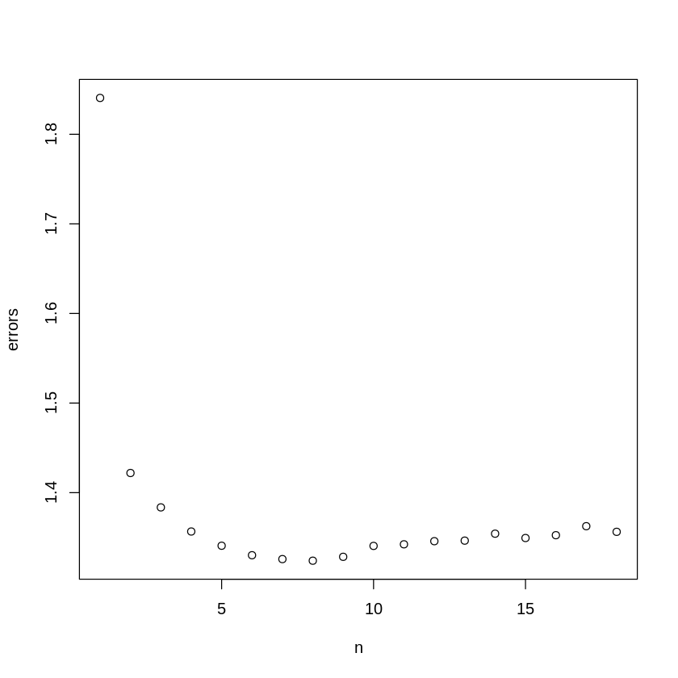

```r
n = seq(1,18)
plot(n, errors)
```

Tel que l'on peut observer sur le graphique ci-haut, l'erreur baisse rapidement pour atteindre un minimum aux alentours de 8 clusters, avant de remonter tranquillement. Il est important de rappeller que cela est pour un sous-ensemble des données initiales, soit seulement 150 users et 200 films, et que les résultats aurait probablement été différents si les calculs avaient été faits sur les données complètes. Avec plus de temps / une meilleure parallélisation / une meilleure utilisation de librairies existantes pour optimiser les opérations matricielles et vectorielles, la même approche peut être effectuée sur les données complètes pour obtenir le nombre de clusters optimal sur toutes les données.

Il serait intéressant également de faire cette expérience sur différentes tailles d'ensemble de données afin d'essayer de déterminer une corrélation entre le nombre de clusters optimal et la quantité de données.